# jsolanm_deep_1

[figure not shown]

M2.875 · Deep Learning · PEC1

2025-2 · Máster universitario en Ciencia de datos (Data science)

Estudios de Informática, Multimedia y Telecomunicación

# PEC 1: Redes neuronales convolucionales con Keras y Pytorch - Clasificación de imágenes satelitales

A lo largo de esta práctica vamos a implementar varios modelos de redes neuronales para clasificar las imágenes de una base de datos de imágenes satelitales. Concretamente se desarrollaran las siguientes tareas:

1. Descarga, análisis y pre-procesado de los datos (1.5 pts)
2. Red neuronal completamente conectada (Dense NN) (1.5 pts)
3. Red convolucional (CNN) pequeña (2 pts)
4. Autoencoders (2 pts)
5. Transfer Learning con modelos eficientes: EfficientNetB0 (2 pts)
6. Introducción a Pytorch: Replicando nuestra CNN (1 pt)

Consideraciones generales:

- La solución propuesta no debe utilizar métodos, funciones o parámetros declarados *deprecated* en versiones futuras.
- Esta PEC se debe hacer de manera **estrictamente individual**. Cualquier indicio de copia será penalizado con un suspenso (D) para todas las partes implicadas y la posible evaluación negativa de la totalidad de la asignatura.
- Es necesario que el estudiante indique **todas las fuentes** que ha utilizado para la realización de la PEC. En caso contrario, se considerará que el alumno ha cometido plagio, siendo penalizado con un suspenso (D) y la posible evaluación negativa de la totalidad de la asignatura.
- Si se utiliza cualquier **IA generativa** en la resolución del PAC **se debe referenciar** en aquellas secciones donde se ha utilizado, como cualquier otra fuente.

Formato de la entrega:

- Algunos ejercicios pueden suponer varios minutos de ejecución, de manera que la entrega se debe hacer en formato **Notebook** y en formato **html**, donde se vea el código, los resultados y los comentarios de cada ejercicio. Podéis exportar el cuaderno a HTML en Jupyter Notebook desde el menú File $\to$ Download as $\to$ HTML.
- Hay un tipo especial de celda para alojar el texto. Este tipo de celdas será muy útil para responder a las diferentes preguntas teóricas planteadas a lo largo de la actividad. Para cambiar el tipo de celda a este tipo, en el menú: Cell $\to$ Cell Type $\to$ Markdown.

Dataset utilizado:

En este PAC utilizaremos **UC Merced Land Use Dataset**, un conjunto de datos de libre acceso que consta de imágenes aéreas de alta resolución (2 m) de una región agrícola en el Valle Central de California.

## 0. Contexto y carga de librerías

Las imágenes tomadas por satélite son clave en la supervisión del uso y la cobertura del suelo, cuestiones relevantes para la gestión ambiental, la planificación urbana, la sostenibilidad y para combatir el cambio climático.

En esta práctica, trabajaremos con la base de datos [UC Merced Land Use Data](https://www.kaggle.com/datasets/zeadomar/uc-mercedland), que consiste en imágenes satelitales de 256x256 píxeles de 21 escenas diferentes: las clases son diversas, y contienen escenas e imágenes de aviones o ríos, entre otras categorías.

Concretamente trabajaremos con una versión aumentada de dicha base de datos que está disponible en un [repositorio de Kaggle](https://www.kaggle.com/datasets/apollo2506/landuse-scene-classification). En esta versión se han llevado a cabo varios procesos de aumentación de datos de tal forma que el número de imágenes por clase pasa de 100 a 500.

**Nota: Se recomienda realizar la práctica en el entorno que ofrece la plataforma Kaggle, ya que ofrece un entorno gratuito con 30 horas semanales de uso de GPU.**

A lo largo de toda la práctica, para la creación de las distintas redes, iremos alternando el uso del modelo [Sequential](https://keras.io/guides/sequential_model/) y el modelo [Functional](https://keras.io/guides/functional_api/) de Keras a través de las clases [Sequential](https://keras.io/api/models/sequential/) y [Model](https://keras.io/api/models/model/) respectivamente.

Empezamos cargando las librerías mas relevantes:

```python
# Importamos tensorflow
import tensorflow as tf
print("TF version   : ", tf.__version__)

# Necesitaremos GPU
print("GPU available: ", tf.config.list_physical_devices('GPU'))

# keras version is 2.11.0
import keras
print("Keras version   : ", keras.__version__)
```

```
TF version   :  2.19.0
GPU available:  [PhysicalDevice(name='/physical_device:GPU:0', device_type='GPU')]
Keras version   :  3.10.0
```

```python
# Importamos los elementos de keras que utilizaremos con mayor frecuencia
from keras.utils import image_dataset_from_directory
from keras.layers import (
    GlobalAveragePooling2D, Flatten,
    Dense, Dropout, Conv2D, Conv2DTranspose, BatchNormalization,
    MaxPooling2D, UpSampling2D, Rescaling, Resizing)
from keras.callbacks import EarlyStopping
from keras.optimizers import Adam
from keras import Sequential, Model
```

```python
# Importamos el resto de librerías que necesitaremos para la PEC
import cv2
import glob
import os
import numpy as np
import matplotlib.pyplot as plt
import pandas as pd
import time
```

## 1. Descarga, análisis y pre-procesado de los datos (1,5 puntos)

En este apartado exploraremos la base de datos y prepararemos la carga de las imágenes para los modelos de los siguientes apartados.

Para la descarga de la base de datos tenemos 2 opciones dependiendo de si decidimos trabajar en local o desde el entorno de Kaggle:

- Si trabajamos en local debemos descargar la base de datos desde el siguiente [enlace](https://www.kaggle.com/datasets/apollo2506/landuse-scene-classification/download?datasetVersionNumber=3) (es un archivo .zip que ocupa 2 GB) y descomprimirlo.
- Si trabajamos desde Kaggle. Debemos subir el Notebook del enunciado a la plataforma (para ello podéis seguir los 6 primeros pasos del siguiente [artículo](https://rajputankit22.medium.com/how-to-upload-my-own-notebook-to-kaggle-2b0dedbb5a6b)) y después, una vez subido el notebook, en la pestaña 'Input', clickar el botón '+ Add Input' y en la caja de búsqueda introducir la dirección 'https://www.kaggle.com/datasets/apollo2506/landuse-scene-classification'. Una vez encontrado el dataset darle al botón '+' (Add Dataset), y desde ese momento ya tendréis accesible la base de datos en la ruta `../input/`.

Una vez tenemos la base de datos accesible vamos a inspeccionarla.

Las imágenes se encuentran agrupadas de 2 formas diferentes:

- En la carpeta `/landuse-scene-classification/images/` se encuentra el total de las imágenes separadas por clases (cada clase en una carpeta distinta). Pero no se ha realizado una separación en conjunto de entrenamiento y test (o entrenamiento, validación y test).
- En la carpeta `/landuse-scene-classification/images_train_test_val/` se encuentran 3 carpetas (`test`, `train` y `validation`) en las que el total de imágenes se ha separado de forma aleatoria. En cada una de las 3 carpetas, tenemos imágenes de las 21 clases agrupadas en sus correspondientes carpetas. En la carpeta raíz `/landuse-scene-classification/` tenemos 3 archivos .csv con la distribución de cada carpeta.

En esta práctica utilizaremos el dataset ya particionado, es decir, trabajaremos con las imágenes que se encuentran en la ruta `/landuse-scene-classification/images_train_test_val/`.

### 1.1. Análisis de los archivos .csv

A partir de los archivos .csv podemos ver cómo se han distribuído los datos. Por ejemplo:

```python
train = pd.read_csv('../input/datasets/apollo2506/landuse-scene-classification/train.csv')
val = pd.read_csv('../input/datasets/apollo2506/landuse-scene-classification/validation.csv')
test = pd.read_csv('../input/datasets/apollo2506/landuse-scene-classification/test.csv')
```

**Ejercicio [0,5 pts.]:** A partir de los 3 archivos .csv se pide:

- Extraer los nombres de las 21 clases (esto sólo hace falta hacerlo en uno de los 3 archivos)
- ¿Cuántas instancias tenemos en total para cada conjunto de datos?
- Comprobar que las clases están balanceadas en los 3 conjuntos de datos (contando para cada conjunto, cuantas instancias/ejemplos tenemos para cada clase)

```python
classes = train["ClassName"].unique()

print("Número de clases:", len(classes))
print("Clases:")
print(classes)
```

```
Número de clases: 21
Clases:
['runway' 'intersection' 'agricultural' 'chaparral' 'airplane'
 'storagetanks' 'tenniscourt' 'overpass' 'harbor' 'buildings'
 'mediumresidential' 'baseballdiamond' 'golfcourse' 'freeway'
 'sparseresidential' 'river' 'mobilehomepark' 'forest' 'beach'
 'parkinglot' 'denseresidential']
```

```python
# Número de instancias por conjunto

print("Train:", len(train))
print("Validation:", len(val))
print("Test:", len(test))
```

```
Train: 7350
Validation: 2100
Test: 1050
```

```python
# Número de instancias por clase

instances = pd.DataFrame({
    "train": train["ClassName"].value_counts(),
    "validation": val["ClassName"].value_counts(),
    "test": test["ClassName"].value_counts()
})

print(instances)
```

```
                   train  validation  test
ClassName
agricultural         350         100    50
airplane             350         100    50
baseballdiamond      350         100    50
beach                350         100    50
buildings            350         100    50
chaparral            350         100    50
denseresidential     350         100    50
forest               350         100    50
freeway              350         100    50
golfcourse           350         100    50
harbor               350         100    50
intersection         350         100    50
mediumresidential    350         100    50
mobilehomepark       350         100    50
overpass             350         100    50
parkinglot           350         100    50
river                350         100    50
runway               350         100    50
sparseresidential    350         100    50
storagetanks         350         100    50
tenniscourt          350         100    50
```

**Comentarios:**  
Tenemos 500 muestras en total para cada una de las 21 clases y se han divido en un 70% para entrenamiento, 20% validación y 10% test.

### 1.2. Análisis de las carpetas de imágenes.

Aunque se supone que cada archivo .csv refleja a la perfección el contenido de cada conjunto de datos, no está demás cerciorarse que el contenido del mismo se corresponde con lo anotado en cada archivo. Para ello se pide:

**Ejercicio[0,5 pts]:** Proporciona, a partir de las carpetas de imágenes, el número de imágenes que tenemos en cada categoría para cada conjunto de datos, comprobando que coincide con lo estipulado en el archivo .csv, y visualiza a modo de ejemplo una imagen por cada categoría. ¿Qué rango dinámico (valores mínimo y máximo) tienen las imágenes?

```python
from PIL import Image

def get_class_paths(dataset: str, base_dir: str):
    search_path = os.path.join(base_dir, dataset)
    class_paths = {}

    for cls in sorted(os.listdir(search_path)):
        cls_path = os.path.join(search_path, cls)
        if os.path.isdir(cls_path):
            class_paths[cls] = cls_path

    return class_paths


def count_images(dataset: str, base_dir: str):
    class_paths = get_class_paths(dataset, base_dir)
    class_counts = {}

    for cls, path in class_paths.items():
        class_counts[cls] = len(os.listdir(path))

    return class_counts


def dynamic_range(dataset: str, base_dir: str):
    ranges = {}
    for cls, path in get_class_paths(dataset, base_dir).items():
        files = os.listdir(path)
        if files:
            img = np.asarray(Image.open(os.path.join(path, files[0])))
            ranges[cls] = (int(img.min()), int(img.max()))
    return ranges
```

```python
base_dir = "../input/datasets/apollo2506/landuse-scene-classification/images_train_test_val"

# Rango dinámico (una imagen por clase, sobre train por ejemplo)
range_df = pd.DataFrame(
    dynamic_range("train", base_dir), index=["min", "max"]
).T.sort_index()

print(range_df)
```

```
                   min  max
agricultural         0  211
airplane             0  206
baseballdiamond      0  250
beach               24  215
buildings            0  255
chaparral           27  255
denseresidential     0  255
forest               0  255
freeway              0  219
golfcourse           0  255
harbor               0  255
intersection         0  255
mediumresidential    0  233
mobilehomepark      29  255
overpass            12  255
parkinglot           0  255
river                0  247
runway               1  255
sparseresidential    1  255
storagetanks         0  248
tenniscourt          0  255
```

```python
# Comparar número de imagenes por categoría por conjunto
# Conteo de instancias
instances_img = pd.DataFrame({
    split: pd.Series(count_images(split, base_dir))
    for split in ["train", "validation", "test"]
}).sort_index()


print(instances_img.equals(instances))
print(instances_img)
```

```
True
                   train  validation  test
agricultural         350         100    50
airplane             350         100    50
baseballdiamond      350         100    50
beach                350         100    50
buildings            350         100    50
chaparral            350         100    50
denseresidential     350         100    50
forest               350         100    50
freeway              350         100    50
golfcourse           350         100    50
harbor               350         100    50
intersection         350         100    50
mediumresidential    350         100    50
mobilehomepark       350         100    50
overpass             350         100    50
parkinglot           350         100    50
river                350         100    50
runway               350         100    50
sparseresidential    350         100    50
storagetanks         350         100    50
tenniscourt          350         100    50
```

### 1.3. Creación de los conjuntos de datos en formato Keras/Tensorflow

 Con el objetivo de crear una base de datos en el formato Keras/Tensorflow a partir de las imágenes proporcionadas utilizaremos la función `tf.keras.utils.image_dataset_from_directory()` ya que nos permite crear bases de datos a partir de imágenes guardadas en carpetas.

La documentación de esta función se encuentra tanto en la web de [Keras](https://keras.io/api/data_loading/image/) como en la de [Tensorflow](https://www.tensorflow.org/api_docs/python/tf/keras/utils/image_dataset_from_directory) .

Además, aprovecharemos para redimensionar las imágenes y pasarlas a tamaño 224x224, que es el tamaño con el que se ha entrenado la red EfficientNetB0 que utilizaremos en un apartado posterior.

**Ejercicio[0,5 pts]:** Utiliza la función `image_dataset_from_directory()` para generar 3 conjuntos de datos (`train_data`, `val_data` y `test_data`) a partir de las carpetas analizadas. Las imágenes deben ser redimensionadas a tamaño 224x224 píxels RGB (224,224,3) y agrupadas en lotes de tamaño 32 (batch=32) manteniendo su rango dinámico.

```python
train_data = tf.keras.utils.image_dataset_from_directory(
    os.path.join(base_dir, "train"),
    image_size=(224, 224),
    batch_size=32,
    shuffle=True
)

val_data = tf.keras.utils.image_dataset_from_directory(
    os.path.join(base_dir, "validation"),
    image_size=(224, 224),
    batch_size=32,
    shuffle=False
)

test_data = tf.keras.utils.image_dataset_from_directory(
    os.path.join(base_dir, "test"),
    image_size=(224, 224),
    batch_size=32,
    shuffle=False
)
```

```
Found 7350 files belonging to 21 classes.
Found 2100 files belonging to 21 classes.
Found 1050 files belonging to 21 classes.
```

## 2. Red neuronal completamente conectada (Dense NN) (1,5 puntos)

En este apartado, vamos a entrenar y evaluar un modelo muy sencillo completamente conectado para establecer un resultado de referencia.

Dado que en una red neuronal artificial las entradas son unidimensionales, lo primero que tenemos que hacer es redimensionar los datos de entrada (las imágenes) para convertirlos en arrays de una dimensión.

Como trabajar con imágenes de tamaño 224x224 en una red completamente conectada implicaría entrenar un número de parámetros excesivamente elevado definiremos un modelo en el que se realizará previamente un redimensionado de las imágenes de entrada a un tamaño de 32x32 y un achatamiento (*flattening*) de los píxeles para así generar un vector unidimensional de tamaño 3072 (32x32x3).

Posteriormente entrenaremos un clasificador (una red completamente conectada) para llevar a cabo la clasificación de nuestros datos.

En este apartado utilizaremos las capas [Resizing](https://keras.io/api/layers/preprocessing_layers/image_preprocessing/resizing/), [Rescaling](https://keras.io/api/layers/preprocessing_layers/image_preprocessing/rescaling/), [Flatten](https://keras.io/api/layers/reshaping_layers/flatten/), [Dense](https://keras.io/api/layers/core_layers/dense/) y [Dropout](https://keras.io/api/layers/regularization_layers/dropout/) de keras.

**Ejercicio:** Implementa un modelo **secuencial** de Keras (a partir de la clase `Sequential()`) con las siguientes especificaciones:

- Una capa que reduzca las dimensiones de entrada de (224,224) a (32,32)
- Una capa de reescalado para conseguir que los valores de la imagen estén entre 0 y 1
- Una capa Flatten para convertir la imagen en un vector de 3072 posiciones
- Una capa completamente conectada de 1024 neuronas y activación ReLU
- Una capa de Dropout (con probabilidad 0.5)
- Una capa de salida completamente conectada correspondiente a la clasificación final cuyo número de neuronas debe ser igual al múmero de clases de la base de datos y con la función de activación adecuada para llevar a cabo esta tarea de clasificación.

Compilar y entrenar el modelo siguiendo las siguientes indicaciones:

- Utilizar el optimizador Adam con *learning rate* de 0.0001.
- Entrenar durante 100 épocas utilizando *EarlyStopping* con una persistencia de 10 épocas, monitorizando la función de pérdida en el conjunto de validación, y guardando los pesos que mejor resultado hayan obtenido.
- Monitorizar la métrica *accuracy* durante entrenamiento y validación.
- Mostrar las gráficas de accuracy y loss. En cada gráfica debe visualizarse la curva de entrenamiento y la de validación. NOTA: Se recomienda hacer una función que imprima ambas gráficas para poder reutilizarla en próximos apartados.
- Realizar la evaluación del modelo una vez ha finalizado el entrenamiento para mostrar la pérdida y la exactitud final sobre los datos de test.

Preguntas a responder: ¿Cúal es el número de parámetros a entrenar? ¿y el tiempo de entrenamiento? ¿Qué precisión se obtiene con este modelo? Comenta los resultados y las gráficas de entrenamiento.  
**NOTA: se recomienda, al final de la creación de cada modelo, utilizar la función `summary()` para comprobar la estructura de la red creada, así como el numero de parámetros que se deben entrenar. Se recomienda hacerlo en todos los ejercicios.**

```python
# Definición de la red

num_classes = len(train_data.class_names)

dense_model = tf.keras.Sequential([
    tf.keras.layers.Resizing(32, 32),
    tf.keras.layers.Rescaling(1./255),
    tf.keras.layers.Flatten(),
    tf.keras.layers.Dense(1024, activation="relu"),
    tf.keras.layers.Dropout(0.5),
    tf.keras.layers.Dense(num_classes, activation="softmax")
])

dense_model.summary()
```

```
Model: "sequential_2"
```

```
┏━━━━━━━━━━━━━━━━━━━━━━━━━━━━━━━━━┳━━━━━━━━━━━━━━━━━━━━━━━━┳━━━━━━━━━━━━━━━┓
┃ Layer (type)                    ┃ Output Shape           ┃       Param # ┃
┡━━━━━━━━━━━━━━━━━━━━━━━━━━━━━━━━━╇━━━━━━━━━━━━━━━━━━━━━━━━╇━━━━━━━━━━━━━━━┩
│ resizing_2 (Resizing)           │ ?                      │   0 (unbuilt) │
├─────────────────────────────────┼────────────────────────┼───────────────┤
│ rescaling_7 (Rescaling)         │ ?                      │   0 (unbuilt) │
├─────────────────────────────────┼────────────────────────┼───────────────┤
│ flatten_2 (Flatten)             │ ?                      │   0 (unbuilt) │
├─────────────────────────────────┼────────────────────────┼───────────────┤
│ dense_9 (Dense)                 │ ?                      │   0 (unbuilt) │
├─────────────────────────────────┼────────────────────────┼───────────────┤
│ dropout_3 (Dropout)             │ ?                      │             0 │
├─────────────────────────────────┼────────────────────────┼───────────────┤
│ dense_10 (Dense)                │ ?                      │   0 (unbuilt) │
└─────────────────────────────────┴────────────────────────┴───────────────┘
```

```
 Total params: 0 (0.00 B)
```

```
 Trainable params: 0 (0.00 B)
```

```
 Non-trainable params: 0 (0.00 B)
```

```python
# Compilación de la red

dense_model.compile(
    optimizer=tf.keras.optimizers.Adam(learning_rate=0.0001),
    loss="sparse_categorical_crossentropy",
    metrics=["accuracy"]
)
```

```python
# Entrenamiento de la red

early_stopping = tf.keras.callbacks.EarlyStopping(
    monitor="val_loss",
    patience=10,
    restore_best_weights=True
)

history_dense = dense_model.fit(
    train_data,
    validation_data=val_data,
    epochs=100,
    callbacks=[early_stopping]
)
```

```
230/230 ━━━━━━━━━━━━━━━━━━━━ 14s 54ms/step - accuracy: 0.0585 - loss: 3.1917 - val_accuracy: 0.0762 - val_loss: 3.0100
230/230 ━━━━━━━━━━━━━━━━━━━━ 11s 48ms/step - accuracy: 0.0812 - loss: 3.0081 - val_accuracy: 0.0929 - val_loss: 2.9856
230/230 ━━━━━━━━━━━━━━━━━━━━ 11s 49ms/step - accuracy: 0.1042 - loss: 2.9670 - val_accuracy: 0.1190 - val_loss: 2.9423
230/230 ━━━━━━━━━━━━━━━━━━━━ 11s 49ms/step - accuracy: 0.1270 - loss: 2.9183 - val_accuracy: 0.1443 - val_loss: 2.9111
230/230 ━━━━━━━━━━━━━━━━━━━━ 11s 48ms/step - accuracy: 0.1350 - loss: 2.8726 - val_accuracy: 0.1414 - val_loss: 2.8762
230/230 ━━━━━━━━━━━━━━━━━━━━ 11s 49ms/step - accuracy: 0.1458 - loss: 2.8407 - val_accuracy: 0.1633 - val_loss: 2.8481
230/230 ━━━━━━━━━━━━━━━━━━━━ 11s 48ms/step - accuracy: 0.1625 - loss: 2.7997 - val_accuracy: 0.1695 - val_loss: 2.8219
230/230 ━━━━━━━━━━━━━━━━━━━━ 11s 48ms/step - accuracy: 0.1770 - loss: 2.7511 - val_accuracy: 0.1700 - val_loss: 2.8018
230/230 ━━━━━━━━━━━━━━━━━━━━ 11s 48ms/step - accuracy: 0.1864 - loss: 2.7138 - val_accuracy: 0.1767 - val_loss: 2.7883
230/230 ━━━━━━━━━━━━━━━━━━━━ 11s 48ms/step - accuracy: 0.1902 - loss: 2.6921 - val_accuracy: 0.1933 - val_loss: 2.7757
230/230 ━━━━━━━━━━━━━━━━━━━━ 11s 48ms/step - accuracy: 0.1949 - loss: 2.6786 - val_accuracy: 0.1976 - val_loss: 2.7519
230/230 ━━━━━━━━━━━━━━━━━━━━ 11s 48ms/step - accuracy: 0.2134 - loss: 2.6295 - val_accuracy: 0.1914 - val_loss: 2.7435
230/230 ━━━━━━━━━━━━━━━━━━━━ 11s 48ms/step - accuracy: 0.2292 - loss: 2.5857 - val_accuracy: 0.1924 - val_loss: 2.7325
230/230 ━━━━━━━━━━━━━━━━━━━━ 11s 49ms/step - accuracy: 0.2431 - loss: 2.5635 - val_accuracy: 0.2014 - val_loss: 2.7171
230/230 ━━━━━━━━━━━━━━━━━━━━ 11s 48ms/step - accuracy: 0.2439 - loss: 2.5397 - val_accuracy: 0.2024 - val_loss: 2.7025
230/230 ━━━━━━━━━━━━━━━━━━━━ 11s 49ms/step - accuracy: 0.2531 - loss: 2.5159 - val_accuracy: 0.2076 - val_loss: 2.6867
230/230 ━━━━━━━━━━━━━━━━━━━━ 11s 48ms/step - accuracy: 0.2566 - loss: 2.4800 - val_accuracy: 0.2019 - val_loss: 2.6926
230/230 ━━━━━━━━━━━━━━━━━━━━ 11s 48ms/step - accuracy: 0.2817 - loss: 2.4558 - val_accuracy: 0.2167 - val_loss: 2.6752
230/230 ━━━━━━━━━━━━━━━━━━━━ 11s 49ms/step - accuracy: 0.2819 - loss: 2.4348 - val_accuracy: 0.2171 - val_loss: 2.6684
230/230 ━━━━━━━━━━━━━━━━━━━━ 11s 49ms/step - accuracy: 0.2896 - loss: 2.4078 - val_accuracy: 0.2133 - val_loss: 2.6567
230/230 ━━━━━━━━━━━━━━━━━━━━ 11s 48ms/step - accuracy: 0.3066 - loss: 2.3649 - val_accuracy: 0.2071 - val_loss: 2.6604
230/230 ━━━━━━━━━━━━━━━━━━━━ 11s 48ms/step - accuracy: 0.3097 - loss: 2.3422 - val_accuracy: 0.2219 - val_loss: 2.6426
230/230 ━━━━━━━━━━━━━━━━━━━━ 11s 48ms/step - accuracy: 0.3227 - loss: 2.3109 - val_accuracy: 0.2095 - val_loss: 2.6462
230/230 ━━━━━━━━━━━━━━━━━━━━ 11s 49ms/step - accuracy: 0.3295 - loss: 2.3028 - val_accuracy: 0.2143 - val_loss: 2.6373
230/230 ━━━━━━━━━━━━━━━━━━━━ 11s 49ms/step - accuracy: 0.3326 - loss: 2.2796 - val_accuracy: 0.2248 - val_loss: 2.6382
230/230 ━━━━━━━━━━━━━━━━━━━━ 11s 48ms/step - accuracy: 0.3515 - loss: 2.2274 - val_accuracy: 0.2143 - val_loss: 2.6299
230/230 ━━━━━━━━━━━━━━━━━━━━ 11s 49ms/step - accuracy: 0.3457 - loss: 2.2125 - val_accuracy: 0.2081 - val_loss: 2.6429
230/230 ━━━━━━━━━━━━━━━━━━━━ 11s 48ms/step - accuracy: 0.3630 - loss: 2.1794 - val_accuracy: 0.2119 - val_loss: 2.6301
230/230 ━━━━━━━━━━━━━━━━━━━━ 11s 48ms/step - accuracy: 0.3588 - loss: 2.1835 - val_accuracy: 0.2262 - val_loss: 2.6074
230/230 ━━━━━━━━━━━━━━━━━━━━ 11s 48ms/step - accuracy: 0.3774 - loss: 2.1490 - val_accuracy: 0.2214 - val_loss: 2.6159
230/230 ━━━━━━━━━━━━━━━━━━━━ 11s 49ms/step - accuracy: 0.3886 - loss: 2.1003 - val_accuracy: 0.2276 - val_loss: 2.6140
230/230 ━━━━━━━━━━━━━━━━━━━━ 11s 49ms/step - accuracy: 0.3959 - loss: 2.0968 - val_accuracy: 0.2190 - val_loss: 2.6245
230/230 ━━━━━━━━━━━━━━━━━━━━ 11s 49ms/step - accuracy: 0.3969 - loss: 2.0619 - val_accuracy: 0.2362 - val_loss: 2.5999
230/230 ━━━━━━━━━━━━━━━━━━━━ 11s 49ms/step - accuracy: 0.4162 - loss: 2.0351 - val_accuracy: 0.2262 - val_loss: 2.6030
230/230 ━━━━━━━━━━━━━━━━━━━━ 11s 49ms/step - accuracy: 0.4095 - loss: 2.0145 - val_accuracy: 0.2281 - val_loss: 2.6169
230/230 ━━━━━━━━━━━━━━━━━━━━ 11s 49ms/step - accuracy: 0.4222 - loss: 1.9928 - val_accuracy: 0.2286 - val_loss: 2.5998
230/230 ━━━━━━━━━━━━━━━━━━━━ 11s 48ms/step - accuracy: 0.4380 - loss: 1.9482 - val_accuracy: 0.2381 - val_loss: 2.6027
230/230 ━━━━━━━━━━━━━━━━━━━━ 11s 48ms/step - accuracy: 0.4540 - loss: 1.9273 - val_accuracy: 0.2419 - val_loss: 2.5985
230/230 ━━━━━━━━━━━━━━━━━━━━ 11s 48ms/step - accuracy: 0.4572 - loss: 1.8931 - val_accuracy: 0.2386 - val_loss: 2.5884
230/230 ━━━━━━━━━━━━━━━━━━━━ 11s 48ms/step - accuracy: 0.4669 - loss: 1.8739 - val_accuracy: 0.2395 - val_loss: 2.5848
```

[output cut: 20 more lines]

```python
def plot_training(history):
    fig, axes = plt.subplots(1, 2, figsize=(14, 4))

    axes[0].plot(history.history["accuracy"], label="train")
    axes[0].plot(history.history["val_accuracy"], label="val")
    axes[0].set_title("Accuracy")
    axes[0].set_xlabel("Época")
    axes[0].legend()

    axes[1].plot(history.history["loss"], label="train")
    axes[1].plot(history.history["val_loss"], label="val")
    axes[1].set_title("Loss")
    axes[1].set_xlabel("Época")
    axes[1].legend()

    plt.tight_layout()
    plt.show()
```

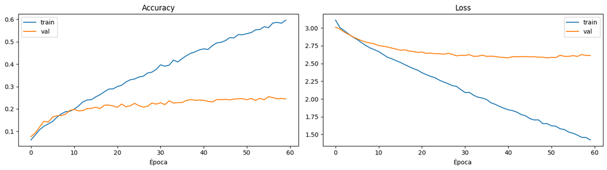

```
33/33 ━━━━━━━━━━━━━━━━━━━━ 2s 48ms/step - accuracy: 0.3041 - loss: 2.4573
Test loss:     2.6227
Test accuracy: 0.2505
```

```python
# Plot del training loss y la accuracy
plot_training(history_dense)

test_loss, test_acc = dense_model.evaluate(test_data)
print(f"Test loss:     {test_loss:.4f}")
print(f"Test accuracy: {test_acc:.4f}")
```

**Comentarios:**  
El número de parámetros es:  
Capa Dense (1024): (3072 entradas * 1024 salidas) + 1024 bias  
Capa Dense (21): (1024 entradas * 21 salidas) + 21 bias  
Total 3.168.277  
El tiempo de entrenamiento, al hacerlo en Kaggle ha sido de aproximadamente 10 minutos.  
En cuanto a su precisión, en validación ha conseguido un máximo de 0.2505 en test  
Además, en este caso de una red muy simple con pocas neuronas podemos ver que tenemos , por una parte malos resultados tanto en precisión y pérdida y además encontramos sobre ajuste. Esto se ve porque los valores de train seguían mejorando mientras los de validación habían llegado a un punto donde se mantenían estables.

## 3. Red convolucional pequeña (2 puntos)

Dadas las bajas prestaciones del modelo anterior vamos a probar otro tipo de redes con el objetivo de obtener unos mejores resultados en la tarea de clasificación que debemos llevar a cabo.

Las redes convolucionales (CNN) son especialmente adecuadas para modelar datos donde hay patrones en 2 dimensiones, como es el caso de las imágenes.

En la tarea de clasificación, la estructura de una CNN se divide en dos grandes bloques:

- **Bloque extractor de características**: En este bloque se generan diferentes niveles de abstracción de la imagen de entrada mediante capas convolucionales. Cuanto más profundas son estas capas, más preparadas están para la tarea de clasificación.
- **Clasificador**: Este bloque está formado por capas totalmente conectadas, la salida de este bloque será la probabilidad asociada a cada clase.

En el apartado anterior, el bloque "extractor de características" era extremadamente simple, por no decir inexistente. En este apartado, vamos a hacer uso de capas convolucionales para poder aprender mejores abstracciones de las imágenes de entrada con el fin de mejorar su clasificación.

En este apartado utilizaremos las capas [Conv2D](https://keras.io/api/layers/convolution_layers/convolution2d/), [MaxPooling2D](https://keras.io/api/layers/pooling_layers/max_pooling2d/), [GlobalAveragePooling2D](https://keras.io/api/layers/pooling_layers/global_average_pooling2d/), [Dense](https://keras.io/api/layers/core_layers/dense/) y [Dropout](https://keras.io/api/layers/regularization_layers/dropout/) de keras.

**Nota: Se recomienda, a partir de este punto realizar el entrenamiento en una máquina con GPU (puede activarse en plataformas como Google Colab o Kaggle) con el fin de reducir los tiempos de entrenamiento.**

**Ejercicio [2 puntos]:** A partir del modelo **funcional** de keras (y la clase `Model()`), implementa una red con las siguientes características:

- Un bloque extractor de características que conste de:
  - Una capa de entrada de dimensiones adecuadas a los datos.
  - Una capa de rescalado para conseguir que los valores de la imagen estén entre 0 y 1.
  - 3 capas convolucionales con tamaño de kernel (5x5) para la primera y (3x3) para las 2 siguientes. Se utilizará padding '*same*' y activación ReLU. El número de filtros para cada capa convolucional será 16, 32 y 64 respectivamente.
  - A cada capa convolucional le sigue una capa de *Max Pooling*
  - Una capa de *average pooling* (GlobalAveragePooling2D) para reducir las dimensiones a un vector de 64 dimensiones.
- El clasificador final sigue la estructura del modelo del apartado anterior:
  - Una capa completamente conectada de 1024 neuronas y activación ReLU
  - Una capa de Dropout (con probabilidad 0.5)
  - Una capa de salida completamente conectada correspondiente a la clasificación final cuyo número de neuronas debe ser igual al múmero de clases de la base de datos y con la función de activación adecuada para llevar a cabo esta tarea de clasificación.

Compilar y entrenar el modelo siguiendo las siguientes indicaciones:

- Utilizar el optimizador Adam con *learning rate* de 0.001.
- Entrenar durante 100 épocas utilizando *EarlyStopping* con una persistencia de 10 épocas, monitorizando la función de pérdida en el conjunto de validación, y guardando los pesos que mejor resultado hayan obtenido.
- Monitorizar la métrica *accuracy* durante entrenamiento y validación.
- Mostrar las gráficas de *accuracy* y *loss*. En cada gráfica debe visualizarse la curva de entrenamiento y la de validación.
- Realizar la evaluación del modelo una vez ha finalizado el entrenamiento para mostrar la pérdida y la exactitud final sobre los datos de test.

Preguntas a responder: ¿Cúal es el número de parámetros a entrenar? ¿y el tiempo de entrenamiento? ¿Qué precisión se obtiene con este modelo? Comenta los resultados y las gráficas de entrenamiento.

```python
# Definición de la red

inputs = tf.keras.Input(shape=(224, 224, 3))

x = tf.keras.layers.Rescaling(1./255)(inputs)

x = tf.keras.layers.Conv2D(16, (5, 5), padding="same", activation="relu")(x)
x = tf.keras.layers.MaxPooling2D()(x)
x = tf.keras.layers.Conv2D(32, (3, 3), padding="same", activation="relu")(x)
x = tf.keras.layers.MaxPooling2D()(x)
x = tf.keras.layers.Conv2D(64, (3, 3), padding="same", activation="relu")(x)
x = tf.keras.layers.MaxPooling2D()(x)

x = tf.keras.layers.GlobalAveragePooling2D()(x)

x = tf.keras.layers.Dense(1024, activation="relu")(x)
x = tf.keras.layers.Dropout(0.5)(x)
outputs = tf.keras.layers.Dense(num_classes, activation="softmax")(x)

cnn_model = tf.keras.Model(inputs, outputs)

cnn_model.summary()
```

```
Model: "functional_6"
```

```
┏━━━━━━━━━━━━━━━━━━━━━━━━━━━━━━━━━┳━━━━━━━━━━━━━━━━━━━━━━━━┳━━━━━━━━━━━━━━━┓
┃ Layer (type)                    ┃ Output Shape           ┃       Param # ┃
┡━━━━━━━━━━━━━━━━━━━━━━━━━━━━━━━━━╇━━━━━━━━━━━━━━━━━━━━━━━━╇━━━━━━━━━━━━━━━┩
│ input_layer_8 (InputLayer)      │ (None, 224, 224, 3)    │             0 │
├─────────────────────────────────┼────────────────────────┼───────────────┤
│ rescaling_8 (Rescaling)         │ (None, 224, 224, 3)    │             0 │
├─────────────────────────────────┼────────────────────────┼───────────────┤
│ conv2d_17 (Conv2D)              │ (None, 224, 224, 16)   │         1,216 │
├─────────────────────────────────┼────────────────────────┼───────────────┤
│ max_pooling2d_9 (MaxPooling2D)  │ (None, 112, 112, 16)   │             0 │
├─────────────────────────────────┼────────────────────────┼───────────────┤
│ conv2d_18 (Conv2D)              │ (None, 112, 112, 32)   │         4,640 │
├─────────────────────────────────┼────────────────────────┼───────────────┤
│ max_pooling2d_10 (MaxPooling2D) │ (None, 56, 56, 32)     │             0 │
├─────────────────────────────────┼────────────────────────┼───────────────┤
│ conv2d_19 (Conv2D)              │ (None, 56, 56, 64)     │        18,496 │
├─────────────────────────────────┼────────────────────────┼───────────────┤
│ max_pooling2d_11 (MaxPooling2D) │ (None, 28, 28, 64)     │             0 │
├─────────────────────────────────┼────────────────────────┼───────────────┤
│ global_average_pooling2d_3      │ (None, 64)             │             0 │
│ (GlobalAveragePooling2D)        │                        │               │
├─────────────────────────────────┼────────────────────────┼───────────────┤
│ dense_11 (Dense)                │ (None, 1024)           │        66,560 │
├─────────────────────────────────┼────────────────────────┼───────────────┤
│ dropout_4 (Dropout)             │ (None, 1024)           │             0 │
├─────────────────────────────────┼────────────────────────┼───────────────┤
│ dense_12 (Dense)                │ (None, 21)             │        21,525 │
└─────────────────────────────────┴────────────────────────┴───────────────┘
```

```
 Total params: 112,437 (439.21 KB)
```

```
 Trainable params: 112,437 (439.21 KB)
```

```
 Non-trainable params: 0 (0.00 B)
```

```python
# Compilación de la red

cnn_model.compile(
    optimizer=tf.keras.optimizers.Adam(learning_rate=0.001),
    loss="sparse_categorical_crossentropy",
    metrics=["accuracy"]
)
```

```python
# Entrenamiento

early_stopping = tf.keras.callbacks.EarlyStopping(
    monitor="val_loss",
    patience=10,
    restore_best_weights=True
)

history_cnn = cnn_model.fit(
    train_data,
    validation_data=val_data,
    epochs=100,
    callbacks=[early_stopping]
)
```

```
230/230 ━━━━━━━━━━━━━━━━━━━━ 17s 61ms/step - accuracy: 0.0690 - loss: 2.9947 - val_accuracy: 0.1352 - val_loss: 2.6993
230/230 ━━━━━━━━━━━━━━━━━━━━ 11s 49ms/step - accuracy: 0.1812 - loss: 2.5885 - val_accuracy: 0.2095 - val_loss: 2.4355
230/230 ━━━━━━━━━━━━━━━━━━━━ 11s 50ms/step - accuracy: 0.2588 - loss: 2.3289 - val_accuracy: 0.3248 - val_loss: 2.0988
230/230 ━━━━━━━━━━━━━━━━━━━━ 11s 50ms/step - accuracy: 0.3352 - loss: 2.0807 - val_accuracy: 0.3629 - val_loss: 2.0003
230/230 ━━━━━━━━━━━━━━━━━━━━ 12s 50ms/step - accuracy: 0.3738 - loss: 1.9223 - val_accuracy: 0.4233 - val_loss: 1.8106
230/230 ━━━━━━━━━━━━━━━━━━━━ 11s 50ms/step - accuracy: 0.4209 - loss: 1.7816 - val_accuracy: 0.4486 - val_loss: 1.6804
230/230 ━━━━━━━━━━━━━━━━━━━━ 12s 50ms/step - accuracy: 0.4494 - loss: 1.6867 - val_accuracy: 0.4814 - val_loss: 1.6071
230/230 ━━━━━━━━━━━━━━━━━━━━ 11s 50ms/step - accuracy: 0.4741 - loss: 1.5950 - val_accuracy: 0.5157 - val_loss: 1.5414
230/230 ━━━━━━━━━━━━━━━━━━━━ 11s 50ms/step - accuracy: 0.4947 - loss: 1.5259 - val_accuracy: 0.5495 - val_loss: 1.4050
230/230 ━━━━━━━━━━━━━━━━━━━━ 12s 50ms/step - accuracy: 0.5240 - loss: 1.3962 - val_accuracy: 0.5510 - val_loss: 1.4022
230/230 ━━━━━━━━━━━━━━━━━━━━ 12s 50ms/step - accuracy: 0.5414 - loss: 1.3579 - val_accuracy: 0.6000 - val_loss: 1.2666
230/230 ━━━━━━━━━━━━━━━━━━━━ 12s 51ms/step - accuracy: 0.5738 - loss: 1.2753 - val_accuracy: 0.5967 - val_loss: 1.2311
230/230 ━━━━━━━━━━━━━━━━━━━━ 12s 51ms/step - accuracy: 0.5816 - loss: 1.2431 - val_accuracy: 0.6019 - val_loss: 1.2250
230/230 ━━━━━━━━━━━━━━━━━━━━ 11s 50ms/step - accuracy: 0.6120 - loss: 1.1625 - val_accuracy: 0.6305 - val_loss: 1.1330
230/230 ━━━━━━━━━━━━━━━━━━━━ 12s 50ms/step - accuracy: 0.6141 - loss: 1.1130 - val_accuracy: 0.6538 - val_loss: 1.0994
230/230 ━━━━━━━━━━━━━━━━━━━━ 11s 50ms/step - accuracy: 0.6222 - loss: 1.1059 - val_accuracy: 0.6667 - val_loss: 1.0488
230/230 ━━━━━━━━━━━━━━━━━━━━ 12s 50ms/step - accuracy: 0.6384 - loss: 1.0582 - val_accuracy: 0.6524 - val_loss: 1.0643
230/230 ━━━━━━━━━━━━━━━━━━━━ 12s 51ms/step - accuracy: 0.6469 - loss: 1.0353 - val_accuracy: 0.6890 - val_loss: 0.9975
230/230 ━━━━━━━━━━━━━━━━━━━━ 12s 50ms/step - accuracy: 0.6605 - loss: 0.9811 - val_accuracy: 0.6790 - val_loss: 0.9736
230/230 ━━━━━━━━━━━━━━━━━━━━ 12s 50ms/step - accuracy: 0.6630 - loss: 0.9775 - val_accuracy: 0.6952 - val_loss: 0.9512
230/230 ━━━━━━━━━━━━━━━━━━━━ 12s 51ms/step - accuracy: 0.6866 - loss: 0.9370 - val_accuracy: 0.6924 - val_loss: 0.9611
230/230 ━━━━━━━━━━━━━━━━━━━━ 12s 51ms/step - accuracy: 0.6838 - loss: 0.9167 - val_accuracy: 0.6267 - val_loss: 1.1763
230/230 ━━━━━━━━━━━━━━━━━━━━ 11s 50ms/step - accuracy: 0.7007 - loss: 0.8939 - val_accuracy: 0.7119 - val_loss: 0.8723
230/230 ━━━━━━━━━━━━━━━━━━━━ 11s 50ms/step - accuracy: 0.7128 - loss: 0.8401 - val_accuracy: 0.7314 - val_loss: 0.8265
230/230 ━━━━━━━━━━━━━━━━━━━━ 11s 50ms/step - accuracy: 0.7138 - loss: 0.8330 - val_accuracy: 0.6890 - val_loss: 0.9407
230/230 ━━━━━━━━━━━━━━━━━━━━ 11s 50ms/step - accuracy: 0.7195 - loss: 0.8073 - val_accuracy: 0.7376 - val_loss: 0.8008
230/230 ━━━━━━━━━━━━━━━━━━━━ 12s 51ms/step - accuracy: 0.7217 - loss: 0.8158 - val_accuracy: 0.7010 - val_loss: 0.9123
230/230 ━━━━━━━━━━━━━━━━━━━━ 12s 50ms/step - accuracy: 0.7289 - loss: 0.8025 - val_accuracy: 0.7486 - val_loss: 0.8014
230/230 ━━━━━━━━━━━━━━━━━━━━ 11s 50ms/step - accuracy: 0.7421 - loss: 0.7530 - val_accuracy: 0.7224 - val_loss: 0.8546
230/230 ━━━━━━━━━━━━━━━━━━━━ 12s 50ms/step - accuracy: 0.7421 - loss: 0.7373 - val_accuracy: 0.7505 - val_loss: 0.7697
230/230 ━━━━━━━━━━━━━━━━━━━━ 12s 50ms/step - accuracy: 0.7615 - loss: 0.6992 - val_accuracy: 0.7462 - val_loss: 0.7703
230/230 ━━━━━━━━━━━━━━━━━━━━ 12s 50ms/step - accuracy: 0.7599 - loss: 0.7005 - val_accuracy: 0.7333 - val_loss: 0.7885
230/230 ━━━━━━━━━━━━━━━━━━━━ 11s 50ms/step - accuracy: 0.7565 - loss: 0.7062 - val_accuracy: 0.7657 - val_loss: 0.7191
230/230 ━━━━━━━━━━━━━━━━━━━━ 11s 49ms/step - accuracy: 0.7738 - loss: 0.6518 - val_accuracy: 0.7667 - val_loss: 0.7097
230/230 ━━━━━━━━━━━━━━━━━━━━ 11s 50ms/step - accuracy: 0.7818 - loss: 0.6322 - val_accuracy: 0.7638 - val_loss: 0.7171
230/230 ━━━━━━━━━━━━━━━━━━━━ 12s 50ms/step - accuracy: 0.7716 - loss: 0.6498 - val_accuracy: 0.7233 - val_loss: 0.8413
230/230 ━━━━━━━━━━━━━━━━━━━━ 11s 49ms/step - accuracy: 0.7832 - loss: 0.6495 - val_accuracy: 0.7629 - val_loss: 0.7162
230/230 ━━━━━━━━━━━━━━━━━━━━ 12s 50ms/step - accuracy: 0.7832 - loss: 0.6180 - val_accuracy: 0.7467 - val_loss: 0.7819
230/230 ━━━━━━━━━━━━━━━━━━━━ 12s 50ms/step - accuracy: 0.7962 - loss: 0.6026 - val_accuracy: 0.7776 - val_loss: 0.7184
230/230 ━━━━━━━━━━━━━━━━━━━━ 11s 49ms/step - accuracy: 0.8030 - loss: 0.5749 - val_accuracy: 0.7752 - val_loss: 0.6662
```

[output cut: 32 more lines]

```
230/230 ━━━━━━━━━━━━━━━━━━━━ 11s 49ms/step - accuracy: 0.8870 - loss: 0.3226 - val_accuracy: 0.8429 - val_loss: 0.4996
230/230 ━━━━━━━━━━━━━━━━━━━━ 11s 49ms/step - accuracy: 0.9032 - loss: 0.2904 - val_accuracy: 0.8543 - val_loss: 0.4777
230/230 ━━━━━━━━━━━━━━━━━━━━ 11s 49ms/step - accuracy: 0.9044 - loss: 0.2732 - val_accuracy: 0.8586 - val_loss: 0.4576
230/230 ━━━━━━━━━━━━━━━━━━━━ 11s 49ms/step - accuracy: 0.9191 - loss: 0.2409 - val_accuracy: 0.8514 - val_loss: 0.4943
230/230 ━━━━━━━━━━━━━━━━━━━━ 11s 49ms/step - accuracy: 0.9040 - loss: 0.2734 - val_accuracy: 0.8757 - val_loss: 0.4111
230/230 ━━━━━━━━━━━━━━━━━━━━ 11s 49ms/step - accuracy: 0.9099 - loss: 0.2548 - val_accuracy: 0.8638 - val_loss: 0.4572
230/230 ━━━━━━━━━━━━━━━━━━━━ 11s 49ms/step - accuracy: 0.9214 - loss: 0.2206 - val_accuracy: 0.8748 - val_loss: 0.4387
230/230 ━━━━━━━━━━━━━━━━━━━━ 11s 49ms/step - accuracy: 0.9166 - loss: 0.2424 - val_accuracy: 0.8690 - val_loss: 0.4331
230/230 ━━━━━━━━━━━━━━━━━━━━ 11s 49ms/step - accuracy: 0.9110 - loss: 0.2549 - val_accuracy: 0.8543 - val_loss: 0.4903
230/230 ━━━━━━━━━━━━━━━━━━━━ 11s 49ms/step - accuracy: 0.9160 - loss: 0.2478 - val_accuracy: 0.8600 - val_loss: 0.4796
230/230 ━━━━━━━━━━━━━━━━━━━━ 11s 48ms/step - accuracy: 0.9148 - loss: 0.2404 - val_accuracy: 0.8490 - val_loss: 0.5002
230/230 ━━━━━━━━━━━━━━━━━━━━ 11s 49ms/step - accuracy: 0.9217 - loss: 0.2147 - val_accuracy: 0.8638 - val_loss: 0.4791
230/230 ━━━━━━━━━━━━━━━━━━━━ 11s 49ms/step - accuracy: 0.9211 - loss: 0.2210 - val_accuracy: 0.8648 - val_loss: 0.4688
230/230 ━━━━━━━━━━━━━━━━━━━━ 12s 50ms/step - accuracy: 0.9286 - loss: 0.2140 - val_accuracy: 0.8700 - val_loss: 0.4474
230/230 ━━━━━━━━━━━━━━━━━━━━ 11s 49ms/step - accuracy: 0.9161 - loss: 0.2383 - val_accuracy: 0.8767 - val_loss: 0.4202
```

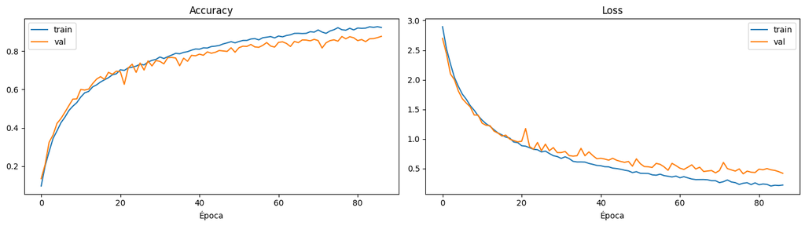

```
33/33 ━━━━━━━━━━━━━━━━━━━━ 2s 50ms/step - accuracy: 0.8734 - loss: 0.3697
Test loss:     0.4067
Test accuracy: 0.8619
```

```python
# Resultados

plot_training(history_cnn)

test_loss, test_acc = cnn_model.evaluate(test_data)
print(f"Test loss:     {test_loss:.4f}")
print(f"Test accuracy: {test_acc:.4f}")
```

## 4. Autoencoders (2 puntos)

En el apartado anterior hemos podido observar que, utilizando el tipo de redes adecuado, podemos obtener mejores resultados entrenando un número de parámetros muy inferior. Esto es debido a que las CNN consiguen extraer las características principales de los datos proporcionados (imágenes en nuestro caso).

En este apartado vamos a observar esta capacidad desde otro punto de vista: el de **codificar y decodificar una imagen**.

Para ello diseñaremos un autoencoder que sea capaz de reducir el tamaño de los datos de entrada pero captando las características principales de las imágenes para poder llevar a cabo una buena reconstrucción de las mismas.

Empezaremos rescalando externamente los datos que vamos a utilizar, para que estén en el rango (0,1), en lugar de realizarlo dentro de la red como hemos hecho en el apartado anterior:

```python
# data rescalling
normalization_layer = Rescaling(1./255)

normalized_train_data = train_data.map(lambda x, y: (normalization_layer(x), y))
normalized_val_data = val_data.map(lambda x, y: (normalization_layer(x), y))
```

Además, en un autoencoder, en lugar de utilizar las etiquetas como objetivo (que es lo que se utiliza en un problema de clasificación), deben ser las propias imágenes las que se utilicen como objetivo de la red. Por tanto, crearemos una nueva base de datos de entrenamiento y validación donde son las propias imágenes las que hagan de etiquetas:

```python
train_data_auto = normalized_train_data.map(lambda x, y: (x, x))
val_data_auto = normalized_val_data.map(lambda x, y: (x, x))
```

Comprobamos la estructura de la nueva base de datos:

```python
image_batch, label_batch = iter(train_data_auto).get_next()
print("Las dimensiones de un batch de imágenes es: {}".format(image_batch.shape))
print("Las dimensiones de un batch de etiquetas es: {}".format(label_batch.shape))
```

```
Las dimensiones de un batch de imágenes es: (32, 224, 224, 3)
Las dimensiones de un batch de etiquetas es: (32, 224, 224, 3)
```

Y que los datos tienen el rango dinámico adecuado:

```python
first_image = image_batch[0]
print("En la primera imagen los valores mínimo y máximo son {} y {}, respectivamente"
      .format(np.min(first_image),np.max(first_image)))
```

```
En la primera imagen los valores mínimo y máximo son 0.0 y 0.9215686917304993, respectivamente
```

### 4.1. Diseño y entrenamiento del autoencoder

Una vez ya tenemos los datos en el formato adecuado vamos a diseñar el autoencoder. Para ello utilizaremos el bloque extractor del apartado anterior como codificador (exceptuando la capa de GlobalAveragePooling, ya que necesitamos preservar la estructura espacial) y reflejaremos su estructura en el decodificador utilizando las capas [Conv2DTranspose](https://keras.io/api/layers/convolution_layers/convolution2d_transpose/) y [UpSampling2D](https://keras.io/api/layers/reshaping_layers/up_sampling2d/) de keras.

**Ejercicio [1 punto]:** A partir del modelo **funcional** de keras (y la clase `Model()`), implementa un autoencoder con las siguientes características:

- El bloque codificador debe tener:
  - Una capa de entrada de dimensiones adecuadas a los datos.
  - 3 capas convolucionales con tamaño de kernel (5x5) para la primera y (3x3) para las 2 siguientes. Se utilizará padding '*same*' y activación ReLU. El número de filtros para cada capa convolucional será 16, 32 y 64 respectivamente.
  - A cada capa convolucional le sigue una capa de *Max Pooling*
- El bloque decodificador debe tener:
  - 3 capas convolucionales con tamaño de kernel (3x3) para las 2 primeras y (5x5) para la última. Se utilizará padding '*same*' y activación ReLU. El número de filtros para cada capa convolucional será 64, 32 y 16, respectivamente
  - A cada capa convolucional le sigue una capa de *UpSampling2D*
  - Una última capa convolucional con tamaño de kernel (3x3), con 3 filtros y activación sigmoide.

Compilar y entrenar el modelo siguiendo las siguientes indicaciones:

- Utilizar el optimizador Adam con *learning rate* de 0.001.
- Utilizar como función de pérdida el error cuadrático medio.
- Entrenar durante 100 épocas utilizando *EarlyStopping* con una persistencia de 10 épocas, monitorizando la función de pérdida en el conjunto de validación, y guardando los pesos que mejor resultado hayan obtenido.
- Monitorizar la pérdida durante entrenamiento y validación.
- Mostrar las gráficas del *loss* (la curva de entrenamiento y la de validación).

```python
# Definición de la red

# Bloque codificador
inputs = tf.keras.Input(shape=(224, 224, 3))

x = tf.keras.layers.Conv2D(16, (5, 5), padding="same", activation="relu")(inputs)
x = tf.keras.layers.MaxPooling2D()(x)
x = tf.keras.layers.Conv2D(32, (3, 3), padding="same", activation="relu")(x)
x = tf.keras.layers.MaxPooling2D()(x)
x = tf.keras.layers.Conv2D(64, (3, 3), padding="same", activation="relu")(x)
x = tf.keras.layers.MaxPooling2D()(x)

# Bloque decodificador
x = tf.keras.layers.Conv2D(64, (3, 3), padding="same", activation="relu")(x)
x = tf.keras.layers.UpSampling2D()(x)
x = tf.keras.layers.Conv2D(32, (3, 3), padding="same", activation="relu")(x)
x = tf.keras.layers.UpSampling2D()(x)
x = tf.keras.layers.Conv2D(16, (5, 5), padding="same", activation="relu")(x)
x = tf.keras.layers.UpSampling2D()(x)

outputs = tf.keras.layers.Conv2D(3, (3, 3), padding="same", activation="sigmoid")(x)

autoencoder = tf.keras.Model(inputs, outputs)

autoencoder.summary()
```

```
Model: "functional_7"
```

```
┏━━━━━━━━━━━━━━━━━━━━━━━━━━━━━━━━━┳━━━━━━━━━━━━━━━━━━━━━━━━┳━━━━━━━━━━━━━━━┓
┃ Layer (type)                    ┃ Output Shape           ┃       Param # ┃
┡━━━━━━━━━━━━━━━━━━━━━━━━━━━━━━━━━╇━━━━━━━━━━━━━━━━━━━━━━━━╇━━━━━━━━━━━━━━━┩
│ input_layer_9 (InputLayer)      │ (None, 224, 224, 3)    │             0 │
├─────────────────────────────────┼────────────────────────┼───────────────┤
│ conv2d_20 (Conv2D)              │ (None, 224, 224, 16)   │         1,216 │
├─────────────────────────────────┼────────────────────────┼───────────────┤
│ max_pooling2d_12 (MaxPooling2D) │ (None, 112, 112, 16)   │             0 │
├─────────────────────────────────┼────────────────────────┼───────────────┤
│ conv2d_21 (Conv2D)              │ (None, 112, 112, 32)   │         4,640 │
├─────────────────────────────────┼────────────────────────┼───────────────┤
│ max_pooling2d_13 (MaxPooling2D) │ (None, 56, 56, 32)     │             0 │
├─────────────────────────────────┼────────────────────────┼───────────────┤
│ conv2d_22 (Conv2D)              │ (None, 56, 56, 64)     │        18,496 │
├─────────────────────────────────┼────────────────────────┼───────────────┤
│ max_pooling2d_14 (MaxPooling2D) │ (None, 28, 28, 64)     │             0 │
├─────────────────────────────────┼────────────────────────┼───────────────┤
│ conv2d_23 (Conv2D)              │ (None, 28, 28, 64)     │        36,928 │
├─────────────────────────────────┼────────────────────────┼───────────────┤
│ up_sampling2d_6 (UpSampling2D)  │ (None, 56, 56, 64)     │             0 │
├─────────────────────────────────┼────────────────────────┼───────────────┤
│ conv2d_24 (Conv2D)              │ (None, 56, 56, 32)     │        18,464 │
├─────────────────────────────────┼────────────────────────┼───────────────┤
│ up_sampling2d_7 (UpSampling2D)  │ (None, 112, 112, 32)   │             0 │
├─────────────────────────────────┼────────────────────────┼───────────────┤
│ conv2d_25 (Conv2D)              │ (None, 112, 112, 16)   │        12,816 │
├─────────────────────────────────┼────────────────────────┼───────────────┤
│ up_sampling2d_8 (UpSampling2D)  │ (None, 224, 224, 16)   │             0 │
├─────────────────────────────────┼────────────────────────┼───────────────┤
│ conv2d_26 (Conv2D)              │ (None, 224, 224, 3)    │           435 │
└─────────────────────────────────┴────────────────────────┴───────────────┘
```

```
 Total params: 92,995 (363.26 KB)
```

```
 Trainable params: 92,995 (363.26 KB)
```

```
 Non-trainable params: 0 (0.00 B)
```

```python
# Compilación de la red

autoencoder.compile(
    optimizer=tf.keras.optimizers.Adam(learning_rate=0.001),
    loss="mse"
)
```

```python
# Entrenamiento de la red

early_stopping = tf.keras.callbacks.EarlyStopping(
    monitor="val_loss",
    patience=10,
    restore_best_weights=True
)

history_auto = autoencoder.fit(
    train_data_auto,
    validation_data=val_data_auto,
    epochs=100,
    callbacks=[early_stopping]
)
```

```
230/230 ━━━━━━━━━━━━━━━━━━━━ 18s 62ms/step - loss: 0.0323 - val_loss: 0.0078
230/230 ━━━━━━━━━━━━━━━━━━━━ 12s 52ms/step - loss: 0.0073 - val_loss: 0.0062
230/230 ━━━━━━━━━━━━━━━━━━━━ 20s 51ms/step - loss: 0.0054 - val_loss: 0.0045
230/230 ━━━━━━━━━━━━━━━━━━━━ 12s 51ms/step - loss: 0.0047 - val_loss: 0.0040
230/230 ━━━━━━━━━━━━━━━━━━━━ 12s 51ms/step - loss: 0.0041 - val_loss: 0.0038
230/230 ━━━━━━━━━━━━━━━━━━━━ 12s 52ms/step - loss: 0.0040 - val_loss: 0.0036
230/230 ━━━━━━━━━━━━━━━━━━━━ 12s 52ms/step - loss: 0.0038 - val_loss: 0.0036
230/230 ━━━━━━━━━━━━━━━━━━━━ 12s 51ms/step - loss: 0.0036 - val_loss: 0.0036
230/230 ━━━━━━━━━━━━━━━━━━━━ 12s 52ms/step - loss: 0.0034 - val_loss: 0.0036
230/230 ━━━━━━━━━━━━━━━━━━━━ 15s 63ms/step - loss: 0.0033 - val_loss: 0.0031
230/230 ━━━━━━━━━━━━━━━━━━━━ 12s 52ms/step - loss: 0.0032 - val_loss: 0.0029
230/230 ━━━━━━━━━━━━━━━━━━━━ 21s 53ms/step - loss: 0.0032 - val_loss: 0.0029
230/230 ━━━━━━━━━━━━━━━━━━━━ 12s 52ms/step - loss: 0.0029 - val_loss: 0.0028
230/230 ━━━━━━━━━━━━━━━━━━━━ 20s 52ms/step - loss: 0.0029 - val_loss: 0.0029
230/230 ━━━━━━━━━━━━━━━━━━━━ 12s 52ms/step - loss: 0.0028 - val_loss: 0.0029
230/230 ━━━━━━━━━━━━━━━━━━━━ 12s 52ms/step - loss: 0.0027 - val_loss: 0.0026
230/230 ━━━━━━━━━━━━━━━━━━━━ 12s 52ms/step - loss: 0.0027 - val_loss: 0.0025
230/230 ━━━━━━━━━━━━━━━━━━━━ 20s 52ms/step - loss: 0.0026 - val_loss: 0.0024
230/230 ━━━━━━━━━━━━━━━━━━━━ 12s 52ms/step - loss: 0.0025 - val_loss: 0.0024
230/230 ━━━━━━━━━━━━━━━━━━━━ 12s 52ms/step - loss: 0.0026 - val_loss: 0.0024
230/230 ━━━━━━━━━━━━━━━━━━━━ 12s 52ms/step - loss: 0.0024 - val_loss: 0.0024
230/230 ━━━━━━━━━━━━━━━━━━━━ 12s 52ms/step - loss: 0.0024 - val_loss: 0.0023
230/230 ━━━━━━━━━━━━━━━━━━━━ 12s 52ms/step - loss: 0.0024 - val_loss: 0.0022
230/230 ━━━━━━━━━━━━━━━━━━━━ 12s 52ms/step - loss: 0.0023 - val_loss: 0.0023
230/230 ━━━━━━━━━━━━━━━━━━━━ 12s 52ms/step - loss: 0.0023 - val_loss: 0.0023
230/230 ━━━━━━━━━━━━━━━━━━━━ 12s 52ms/step - loss: 0.0023 - val_loss: 0.0022
230/230 ━━━━━━━━━━━━━━━━━━━━ 12s 52ms/step - loss: 0.0022 - val_loss: 0.0022
230/230 ━━━━━━━━━━━━━━━━━━━━ 12s 52ms/step - loss: 0.0022 - val_loss: 0.0021
230/230 ━━━━━━━━━━━━━━━━━━━━ 12s 53ms/step - loss: 0.0022 - val_loss: 0.0021
230/230 ━━━━━━━━━━━━━━━━━━━━ 12s 52ms/step - loss: 0.0021 - val_loss: 0.0020
230/230 ━━━━━━━━━━━━━━━━━━━━ 20s 52ms/step - loss: 0.0025 - val_loss: 0.0020
230/230 ━━━━━━━━━━━━━━━━━━━━ 12s 52ms/step - loss: 0.0021 - val_loss: 0.0020
230/230 ━━━━━━━━━━━━━━━━━━━━ 12s 52ms/step - loss: 0.0021 - val_loss: 0.0020
230/230 ━━━━━━━━━━━━━━━━━━━━ 12s 52ms/step - loss: 0.0020 - val_loss: 0.0020
230/230 ━━━━━━━━━━━━━━━━━━━━ 12s 52ms/step - loss: 0.0020 - val_loss: 0.0020
230/230 ━━━━━━━━━━━━━━━━━━━━ 12s 52ms/step - loss: 0.0020 - val_loss: 0.0019
230/230 ━━━━━━━━━━━━━━━━━━━━ 12s 52ms/step - loss: 0.0020 - val_loss: 0.0020
230/230 ━━━━━━━━━━━━━━━━━━━━ 12s 52ms/step - loss: 0.0020 - val_loss: 0.0020
230/230 ━━━━━━━━━━━━━━━━━━━━ 12s 51ms/step - loss: 0.0020 - val_loss: 0.0019
230/230 ━━━━━━━━━━━━━━━━━━━━ 12s 52ms/step - loss: 0.0020 - val_loss: 0.0019
```

[output cut: 45 more lines]

```
230/230 ━━━━━━━━━━━━━━━━━━━━ 12s 52ms/step - loss: 0.0015 - val_loss: 0.0014
230/230 ━━━━━━━━━━━━━━━━━━━━ 12s 52ms/step - loss: 0.0015 - val_loss: 0.0015
230/230 ━━━━━━━━━━━━━━━━━━━━ 12s 52ms/step - loss: 0.0015 - val_loss: 0.0014
230/230 ━━━━━━━━━━━━━━━━━━━━ 12s 52ms/step - loss: 0.0015 - val_loss: 0.0015
230/230 ━━━━━━━━━━━━━━━━━━━━ 12s 52ms/step - loss: 0.0015 - val_loss: 0.0016
230/230 ━━━━━━━━━━━━━━━━━━━━ 12s 52ms/step - loss: 0.0016 - val_loss: 0.0015
230/230 ━━━━━━━━━━━━━━━━━━━━ 12s 52ms/step - loss: 0.0015 - val_loss: 0.0014
230/230 ━━━━━━━━━━━━━━━━━━━━ 12s 51ms/step - loss: 0.0015 - val_loss: 0.0015
230/230 ━━━━━━━━━━━━━━━━━━━━ 12s 51ms/step - loss: 0.0015 - val_loss: 0.0014
230/230 ━━━━━━━━━━━━━━━━━━━━ 12s 52ms/step - loss: 0.0015 - val_loss: 0.0014
230/230 ━━━━━━━━━━━━━━━━━━━━ 12s 52ms/step - loss: 0.0015 - val_loss: 0.0014
230/230 ━━━━━━━━━━━━━━━━━━━━ 12s 52ms/step - loss: 0.0015 - val_loss: 0.0014
230/230 ━━━━━━━━━━━━━━━━━━━━ 12s 52ms/step - loss: 0.0015 - val_loss: 0.0014
230/230 ━━━━━━━━━━━━━━━━━━━━ 20s 51ms/step - loss: 0.0018 - val_loss: 0.0014
230/230 ━━━━━━━━━━━━━━━━━━━━ 12s 51ms/step - loss: 0.0015 - val_loss: 0.0014
```

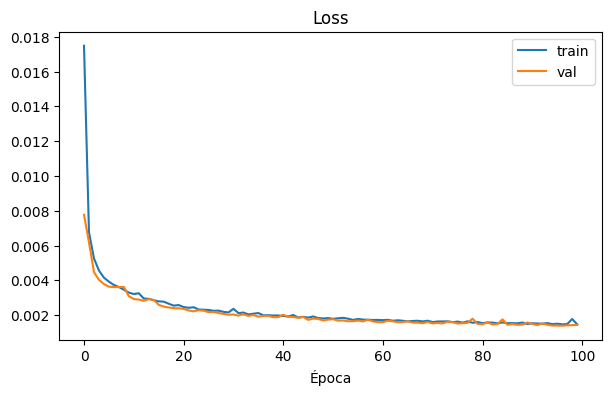

```python
# Representación del loss

plt.figure(figsize=(7, 4))
plt.plot(history_auto.history["loss"], label="train")
plt.plot(history_auto.history["val_loss"], label="val")
plt.title("Loss")
plt.xlabel("Época")
plt.legend()
plt.show()
```

### 4.2. Evaluación del autoencoder

La evaluación del modelo obtenido puede hacerse en este caso tanto de forma cuantitativa (calculando el MSE entre las imágenes originales y reconstruídas del conjunto de test) como cualitativa (mostrando imágenes originales y reconstruídas).

**Ejercicio [1 punto]:** Realizar las siguientes operaciones para evaluar las prestaciones del modelo obtenido:

- Partiendo del conjunto de test obtenido en el primer apartado de la practica:
  - Llevar a cabo el reescalado de los datos utilizando la capa `normalization_layer` tal y como se ha hecho con los conjuntos de entrenamiento y test al inicio de este bloque.
  - Generar el conjunto de datos `test_data_auto` en el que las imágenes sean también el objetivo y substituyan a las etiquetas.
- Realizar la evaluación del modelo una vez ha finalizado el entrenamiento para mostrar la pérdida final a partir de los datos de test.
- Imprimir por pantalla 4 parejas de imágenes (original y reconstruída). Nota: a la hora de representar las imágenes correctamente, recordad que su rango dinámico deben ser números enteros entre 0 y 255.

Preguntas: ¿Consideras que la reconstrucción es adecuada? ¿Qué *ratio* de compresión se consigue con este autoencoder? Consideramos como *ratio* de compresión la relación entre el tamaño original de la imagen (224,224,3) y el de la representación más perqueña que llega a hacer el codificador (tamaño de la salida de su última capa).

```python
# Normalización de los datos

normalized_test_data = test_data.map(lambda x, y: (normalization_layer(x), y))
test_data_auto = normalized_test_data.map(lambda x, y: (x, x))
```

```python
# Evaluación del modelo

test_loss = autoencoder.evaluate(test_data_auto)
print(f"Test loss: {test_loss:.4f}")
```

```
33/33 ━━━━━━━━━━━━━━━━━━━━ 2s 51ms/step - loss: 0.0014
Test loss: 0.0014
```

```
1/1 ━━━━━━━━━━━━━━━━━━━━ 1s 617ms/step
```

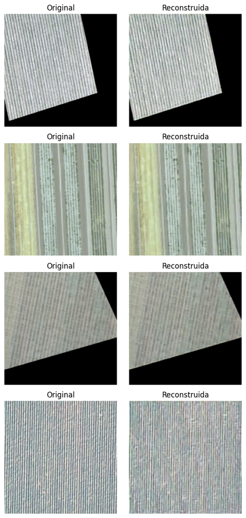

```python
# Visualización de los datos

image_batch, _ = iter(test_data_auto).get_next()
reconstructed = autoencoder.predict(image_batch)

fig, axes = plt.subplots(4, 2, figsize=(6, 12))

for i in range(4):
    original = (image_batch[i].numpy() * 255).astype(int)
    reconstruida = (reconstructed[i] * 255).astype(int)

    axes[i, 0].imshow(original)
    axes[i, 0].set_title("Original")
    axes[i, 0].axis("off")

    axes[i, 1].imshow(reconstruida)
    axes[i, 1].set_title("Reconstruida")
    axes[i, 1].axis("off")

plt.tight_layout()
plt.show()
```

**Comentarios:**  
La versión más pequeña, cuando llega al medio del enconder ha pasado por 3 capas MaxPooling2D que divide las dimensiones por 2 y por la salida de la Conv2D(64).  
Por lo tanto, la representación comprimida tiene(224/8) × (224/8) × 64 = 50.176 valores. Un tercio de su versión original.  
Tras ver las imágenes la reconstrucción de estas mantiene bastante bien la forma general y colores generales. Simplemente se pierde algo de nitidez, cuando hay muchos colores juntos se pierde calidad, se puede ver mejor en las fotografías 1 y 4 pero por lo general es una muy buena reconstrucción teniendo en cuenta la reducción aplicada.

## 5. Transfer learning con modelos eficientes: EfficientNetB0 (2 puntos)

Las redes neuronales convolucionales profundas nos brindan la posibilidad de mejorar la capacidad de aprendizaje de un modelo. Arquitecturas clásicas como VGG16 fueron pioneras, pero hoy en día existen familias de modelos mucho más optimizadas, como **EfficientNet**, que logran mejores precisiones con muchos menos parámetros.

### 5.1. Transfer Learning

En este apartado, aplicaremos [transfer learning](https://keras.io/guides/transfer_learning/) utilizando el modelo [EfficientNetB0](https://keras.io/api/applications/efficientnet/#efficientnetb0-function) preentrenado en [Imagenet](http://www.image-net.org/). Lo adaptaremos para clasificar las 21 categorías de nuestra base de datos. Una gran ventaja de EfficientNet en Keras es que **ya incluye la capa de preprocesamiento (reescalado) internamente**, por lo que podemos pasarle directamente nuestras imágenes en el rango [0, 255].

**Ejercicio[1 punto]:** Implementa una red siguiendo los siguientes pasos:

- Partir del modelo EfficientNetB0 con los pesos entrenados en Imagenet (sin la parte superior de clasificación, `include_top=False`) y congelarlos.
- Añadir una capa `GlobalAveragePooling2D` a la salida del modelo base.
- Añadir una capa densa de 50 neuronas con activación ReLU, seguida de la capa de salida con el número de neuronas adecuado para llevar a cabo la clasificación y la función de activación correspondiente.

Compilar y entrenar el modelo siguiendo las siguientes indicaciones:

- Utilizar el optimizador Adam con *learning rate* de 0.0001.
- Entrenar durante 100 épocas utilizando *EarlyStopping* con una persistencia de 10 épocas, monitorizando la *accuracy* en validación y guardando los mejores pesos.
- Mostrar las gráficas de accuracy y loss (entrenamiento y validación).
- Evaluar el modelo final sobre los datos de test.

Preguntas a responder: ¿Cuál es el número de parámetros a entrenar? ¿Qué precisión se obtiene comparado con la red convolucional simple del apartado 3? Comenta los resultados y las gráficas de entrenamiento.

```python
from tensorflow.keras.applications import EfficientNetB0

# Cargar el modelo base preentrenado
base_model = tf.keras.applications.EfficientNetB0(
    include_top=False,
    input_shape=(224, 224, 3)
)
base_model.trainable = False

print(f"Número de capas del modelo base: {len(base_model.layers)}")
print(f"Parámetros entrenables: {base_model.count_params()}")
```

```
Número de capas del modelo base: 238
Parámetros entrenables: 4049571
```

```python
# Definición de la red
inputs = tf.keras.Input(shape=(224, 224, 3))

x = base_model(inputs, training=False)
x = tf.keras.layers.GlobalAveragePooling2D()(x)
x = tf.keras.layers.Dense(50, activation="relu")(x)
outputs = tf.keras.layers.Dense(num_classes, activation="softmax")(x)

efficientnet_model = tf.keras.Model(inputs, outputs)

efficientnet_model.summary()
```

```
Model: "functional_8"
```

```
┏━━━━━━━━━━━━━━━━━━━━━━━━━━━━━━━━━┳━━━━━━━━━━━━━━━━━━━━━━━━┳━━━━━━━━━━━━━━━┓
┃ Layer (type)                    ┃ Output Shape           ┃       Param # ┃
┡━━━━━━━━━━━━━━━━━━━━━━━━━━━━━━━━━╇━━━━━━━━━━━━━━━━━━━━━━━━╇━━━━━━━━━━━━━━━┩
│ input_layer_11 (InputLayer)     │ (None, 224, 224, 3)    │             0 │
├─────────────────────────────────┼────────────────────────┼───────────────┤
│ efficientnetb0 (Functional)     │ (None, 7, 7, 1280)     │     4,049,571 │
├─────────────────────────────────┼────────────────────────┼───────────────┤
│ global_average_pooling2d_4      │ (None, 1280)           │             0 │
│ (GlobalAveragePooling2D)        │                        │               │
├─────────────────────────────────┼────────────────────────┼───────────────┤
│ dense_13 (Dense)                │ (None, 50)             │        64,050 │
├─────────────────────────────────┼────────────────────────┼───────────────┤
│ dense_14 (Dense)                │ (None, 21)             │         1,071 │
└─────────────────────────────────┴────────────────────────┴───────────────┘
```

```
 Total params: 4,114,692 (15.70 MB)
```

```
 Trainable params: 65,121 (254.38 KB)
```

```
 Non-trainable params: 4,049,571 (15.45 MB)
```

```python
# Compilación de la red
efficientnet_model.compile(
    optimizer=tf.keras.optimizers.Adam(learning_rate=0.0001),
    loss="sparse_categorical_crossentropy",
    metrics=["accuracy"]
)
```

```python
# Entrenamiento de la red
early_stopping = tf.keras.callbacks.EarlyStopping(
    monitor="val_accuracy",
    patience=10,
    restore_best_weights=True
)

history_efficientnet = efficientnet_model.fit(
    train_data,
    validation_data=val_data,
    epochs=100,
    callbacks=[early_stopping]
)
```

```
230/230 ━━━━━━━━━━━━━━━━━━━━ 56s 154ms/step - accuracy: 0.2332 - loss: 2.6855 - val_accuracy: 0.7267 - val_loss: 1.5508
230/230 ━━━━━━━━━━━━━━━━━━━━ 12s 52ms/step - accuracy: 0.7709 - loss: 1.3096 - val_accuracy: 0.8562 - val_loss: 0.8087
230/230 ━━━━━━━━━━━━━━━━━━━━ 12s 52ms/step - accuracy: 0.8758 - loss: 0.7266 - val_accuracy: 0.8867 - val_loss: 0.5528
230/230 ━━━━━━━━━━━━━━━━━━━━ 12s 52ms/step - accuracy: 0.8947 - loss: 0.5174 - val_accuracy: 0.9038 - val_loss: 0.4303
230/230 ━━━━━━━━━━━━━━━━━━━━ 12s 51ms/step - accuracy: 0.9155 - loss: 0.4055 - val_accuracy: 0.9148 - val_loss: 0.3571
230/230 ━━━━━━━━━━━━━━━━━━━━ 12s 51ms/step - accuracy: 0.9237 - loss: 0.3381 - val_accuracy: 0.9267 - val_loss: 0.3081
230/230 ━━━━━━━━━━━━━━━━━━━━ 12s 51ms/step - accuracy: 0.9356 - loss: 0.2881 - val_accuracy: 0.9352 - val_loss: 0.2742
230/230 ━━━━━━━━━━━━━━━━━━━━ 14s 63ms/step - accuracy: 0.9426 - loss: 0.2522 - val_accuracy: 0.9410 - val_loss: 0.2474
230/230 ━━━━━━━━━━━━━━━━━━━━ 12s 51ms/step - accuracy: 0.9516 - loss: 0.2213 - val_accuracy: 0.9443 - val_loss: 0.2258
230/230 ━━━━━━━━━━━━━━━━━━━━ 12s 52ms/step - accuracy: 0.9526 - loss: 0.2044 - val_accuracy: 0.9495 - val_loss: 0.2096
230/230 ━━━━━━━━━━━━━━━━━━━━ 12s 51ms/step - accuracy: 0.9580 - loss: 0.1831 - val_accuracy: 0.9533 - val_loss: 0.1927
230/230 ━━━━━━━━━━━━━━━━━━━━ 12s 51ms/step - accuracy: 0.9628 - loss: 0.1682 - val_accuracy: 0.9548 - val_loss: 0.1804
230/230 ━━━━━━━━━━━━━━━━━━━━ 12s 52ms/step - accuracy: 0.9686 - loss: 0.1500 - val_accuracy: 0.9552 - val_loss: 0.1696
230/230 ━━━━━━━━━━━━━━━━━━━━ 12s 51ms/step - accuracy: 0.9723 - loss: 0.1368 - val_accuracy: 0.9605 - val_loss: 0.1603
230/230 ━━━━━━━━━━━━━━━━━━━━ 12s 52ms/step - accuracy: 0.9723 - loss: 0.1300 - val_accuracy: 0.9619 - val_loss: 0.1524
230/230 ━━━━━━━━━━━━━━━━━━━━ 12s 51ms/step - accuracy: 0.9758 - loss: 0.1182 - val_accuracy: 0.9619 - val_loss: 0.1456
230/230 ━━━━━━━━━━━━━━━━━━━━ 12s 52ms/step - accuracy: 0.9772 - loss: 0.1120 - val_accuracy: 0.9652 - val_loss: 0.1381
230/230 ━━━━━━━━━━━━━━━━━━━━ 12s 53ms/step - accuracy: 0.9808 - loss: 0.1052 - val_accuracy: 0.9662 - val_loss: 0.1309
230/230 ━━━━━━━━━━━━━━━━━━━━ 12s 51ms/step - accuracy: 0.9824 - loss: 0.0968 - val_accuracy: 0.9652 - val_loss: 0.1265
230/230 ━━━━━━━━━━━━━━━━━━━━ 12s 51ms/step - accuracy: 0.9845 - loss: 0.0900 - val_accuracy: 0.9676 - val_loss: 0.1218
230/230 ━━━━━━━━━━━━━━━━━━━━ 12s 51ms/step - accuracy: 0.9851 - loss: 0.0840 - val_accuracy: 0.9671 - val_loss: 0.1161
230/230 ━━━━━━━━━━━━━━━━━━━━ 12s 51ms/step - accuracy: 0.9849 - loss: 0.0812 - val_accuracy: 0.9671 - val_loss: 0.1121
230/230 ━━━━━━━━━━━━━━━━━━━━ 12s 52ms/step - accuracy: 0.9867 - loss: 0.0765 - val_accuracy: 0.9671 - val_loss: 0.1093
230/230 ━━━━━━━━━━━━━━━━━━━━ 12s 52ms/step - accuracy: 0.9865 - loss: 0.0712 - val_accuracy: 0.9686 - val_loss: 0.1046
230/230 ━━━━━━━━━━━━━━━━━━━━ 12s 51ms/step - accuracy: 0.9886 - loss: 0.0685 - val_accuracy: 0.9705 - val_loss: 0.1022
230/230 ━━━━━━━━━━━━━━━━━━━━ 12s 51ms/step - accuracy: 0.9882 - loss: 0.0663 - val_accuracy: 0.9695 - val_loss: 0.1002
230/230 ━━━━━━━━━━━━━━━━━━━━ 12s 51ms/step - accuracy: 0.9901 - loss: 0.0598 - val_accuracy: 0.9714 - val_loss: 0.0960
230/230 ━━━━━━━━━━━━━━━━━━━━ 12s 51ms/step - accuracy: 0.9926 - loss: 0.0546 - val_accuracy: 0.9710 - val_loss: 0.0935
230/230 ━━━━━━━━━━━━━━━━━━━━ 12s 51ms/step - accuracy: 0.9915 - loss: 0.0555 - val_accuracy: 0.9710 - val_loss: 0.0912
230/230 ━━━━━━━━━━━━━━━━━━━━ 12s 52ms/step - accuracy: 0.9926 - loss: 0.0522 - val_accuracy: 0.9714 - val_loss: 0.0894
230/230 ━━━━━━━━━━━━━━━━━━━━ 12s 52ms/step - accuracy: 0.9951 - loss: 0.0488 - val_accuracy: 0.9729 - val_loss: 0.0874
230/230 ━━━━━━━━━━━━━━━━━━━━ 12s 51ms/step - accuracy: 0.9948 - loss: 0.0459 - val_accuracy: 0.9729 - val_loss: 0.0854
230/230 ━━━━━━━━━━━━━━━━━━━━ 12s 52ms/step - accuracy: 0.9942 - loss: 0.0448 - val_accuracy: 0.9738 - val_loss: 0.0830
230/230 ━━━━━━━━━━━━━━━━━━━━ 12s 52ms/step - accuracy: 0.9943 - loss: 0.0413 - val_accuracy: 0.9733 - val_loss: 0.0806
230/230 ━━━━━━━━━━━━━━━━━━━━ 12s 52ms/step - accuracy: 0.9948 - loss: 0.0398 - val_accuracy: 0.9743 - val_loss: 0.0794
230/230 ━━━━━━━━━━━━━━━━━━━━ 12s 51ms/step - accuracy: 0.9946 - loss: 0.0391 - val_accuracy: 0.9733 - val_loss: 0.0790
230/230 ━━━━━━━━━━━━━━━━━━━━ 12s 51ms/step - accuracy: 0.9953 - loss: 0.0368 - val_accuracy: 0.9743 - val_loss: 0.0781
230/230 ━━━━━━━━━━━━━━━━━━━━ 12s 53ms/step - accuracy: 0.9959 - loss: 0.0338 - val_accuracy: 0.9757 - val_loss: 0.0752
230/230 ━━━━━━━━━━━━━━━━━━━━ 12s 52ms/step - accuracy: 0.9975 - loss: 0.0316 - val_accuracy: 0.9738 - val_loss: 0.0743
230/230 ━━━━━━━━━━━━━━━━━━━━ 12s 52ms/step - accuracy: 0.9982 - loss: 0.0285 - val_accuracy: 0.9762 - val_loss: 0.0743
```

[output cut: 21 more lines]

```
230/230 ━━━━━━━━━━━━━━━━━━━━ 12s 51ms/step - accuracy: 0.9975 - loss: 0.0147 - val_accuracy: 0.9810 - val_loss: 0.0580
230/230 ━━━━━━━━━━━━━━━━━━━━ 12s 51ms/step - accuracy: 0.9981 - loss: 0.0135 - val_accuracy: 0.9800 - val_loss: 0.0577
230/230 ━━━━━━━━━━━━━━━━━━━━ 12s 51ms/step - accuracy: 0.9998 - loss: 0.0116 - val_accuracy: 0.9810 - val_loss: 0.0548
230/230 ━━━━━━━━━━━━━━━━━━━━ 12s 51ms/step - accuracy: 0.9993 - loss: 0.0126 - val_accuracy: 0.9795 - val_loss: 0.0586
230/230 ━━━━━━━━━━━━━━━━━━━━ 12s 51ms/step - accuracy: 0.9984 - loss: 0.0139 - val_accuracy: 0.9819 - val_loss: 0.0552
230/230 ━━━━━━━━━━━━━━━━━━━━ 12s 51ms/step - accuracy: 0.9989 - loss: 0.0122 - val_accuracy: 0.9800 - val_loss: 0.0550
230/230 ━━━━━━━━━━━━━━━━━━━━ 12s 52ms/step - accuracy: 0.9989 - loss: 0.0116 - val_accuracy: 0.9805 - val_loss: 0.0540
230/230 ━━━━━━━━━━━━━━━━━━━━ 12s 51ms/step - accuracy: 0.9988 - loss: 0.0110 - val_accuracy: 0.9814 - val_loss: 0.0543
230/230 ━━━━━━━━━━━━━━━━━━━━ 12s 51ms/step - accuracy: 0.9994 - loss: 0.0092 - val_accuracy: 0.9810 - val_loss: 0.0544
230/230 ━━━━━━━━━━━━━━━━━━━━ 12s 51ms/step - accuracy: 0.9995 - loss: 0.0096 - val_accuracy: 0.9810 - val_loss: 0.0553
230/230 ━━━━━━━━━━━━━━━━━━━━ 12s 51ms/step - accuracy: 0.9992 - loss: 0.0100 - val_accuracy: 0.9810 - val_loss: 0.0538
230/230 ━━━━━━━━━━━━━━━━━━━━ 12s 51ms/step - accuracy: 0.9978 - loss: 0.0112 - val_accuracy: 0.9795 - val_loss: 0.0538
230/230 ━━━━━━━━━━━━━━━━━━━━ 12s 52ms/step - accuracy: 0.9991 - loss: 0.0089 - val_accuracy: 0.9790 - val_loss: 0.0531
230/230 ━━━━━━━━━━━━━━━━━━━━ 14s 61ms/step - accuracy: 0.9990 - loss: 0.0093 - val_accuracy: 0.9810 - val_loss: 0.0525
230/230 ━━━━━━━━━━━━━━━━━━━━ 12s 51ms/step - accuracy: 0.9996 - loss: 0.0078 - val_accuracy: 0.9810 - val_loss: 0.0554
```

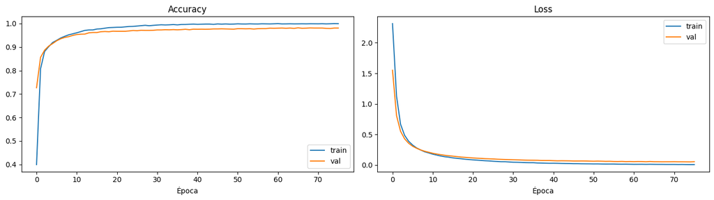

```python
# Resultados
plot_training(history_efficientnet)
```

```python
test_loss, test_acc = efficientnet_model.evaluate(test_data)
print(f"Test loss:     {test_loss:.4f}")
print(f"Test accuracy: {test_acc:.4f}")
```

```
33/33 ━━━━━━━━━━━━━━━━━━━━ 8s 235ms/step - accuracy: 0.9765 - loss: 0.0536
Test loss:     0.0567
Test accuracy: 0.9762
```

**Comentarios:**  
Para mirar los parámetros a entrenar de este caso es mejor mirar el summary() del modelo. Al ser un modelo especial el enunciado dice de aplicarle transfer learning(utilizar parámetros aprendidos en otro problema para pasarlos a este), esto hace, como vemos en el summary que tengamos dos tipos de parámetros:  
Trainable params: 65,121 (254.38 KB)  
Non-trainable params: 4,049,571 (15.45 MB)  
Los entrenables son justamente los que nosotros definimos en las capas de la red neuronal y los no entrenables los que vienen dados por el transfer learning.  
En el apartado 3 hemos obtenido una precisión del 0.8619, en este modelo en cambio hemos obtenido un 0.9762. Esta mejora podemos entenderla justamente por el transfer learning ya que, podemos ver también, que la tasa de accuracy en las primeros epochs son mucho más altas comparadas con la red convolucional del modelo 3 debido a que ya tenía parámetros con pesos entrenados para este tipo de problemas.

### 5.2. Fine-tunning

Para mejorar los resultados del *transfer learning*, aplicaremos *fine-tunning*, que consiste en descongelar el modelo base y reentrenar la red completa durante unas pocas épocas con un *learning rate* muy pequeño para ajustar los pesos finamente a nuestro dominio.

**Ejercicio[1 punto]:** Volver a compilar el modelo con los siguientes cambios:

- Descongelar los pesos del modelo EfficientNetB0 (`base_model_eff.trainable = True`).

Compilar y entrenar el modelo siguiendo las siguientes indicaciones:

- Utilizar el optimizador Adam con *learning rate* de 0.00001.
- Entrenar durante 10 épocas.
- Mostrar las gráficas y realizar la evaluación final sobre los datos de test.

Comenta los resultados globales del proceso.

```python
# Definición del modelo
base_model.trainable = True
```

```python
# Compilación de la red
efficientnet_model.compile(
    optimizer=tf.keras.optimizers.Adam(learning_rate=0.00001),
    loss="sparse_categorical_crossentropy",
    metrics=["accuracy"]
)
```

```python
# Entrenamiento
history_ft = efficientnet_model.fit(
    train_data,
    validation_data=val_data,
    epochs=10
)
```

[output not shown]

```
229/230 ━━━━━━━━━━━━━━━━━━━━ 0s 109ms/step - accuracy: 0.7388 - loss: 0.9066
```

[output not shown]

```
230/230 ━━━━━━━━━━━━━━━━━━━━ 143s 321ms/step - accuracy: 0.7392 - loss: 0.9053 - val_accuracy: 0.9329 - val_loss: 0.2488
230/230 ━━━━━━━━━━━━━━━━━━━━ 28s 120ms/step - accuracy: 0.8750 - loss: 0.4648 - val_accuracy: 0.9381 - val_loss: 0.2358
230/230 ━━━━━━━━━━━━━━━━━━━━ 28s 120ms/step - accuracy: 0.9233 - loss: 0.2794 - val_accuracy: 0.9538 - val_loss: 0.1871
230/230 ━━━━━━━━━━━━━━━━━━━━ 28s 120ms/step - accuracy: 0.9467 - loss: 0.2054 - val_accuracy: 0.9629 - val_loss: 0.1514
230/230 ━━━━━━━━━━━━━━━━━━━━ 28s 120ms/step - accuracy: 0.9551 - loss: 0.1649 - val_accuracy: 0.9681 - val_loss: 0.1301
230/230 ━━━━━━━━━━━━━━━━━━━━ 28s 120ms/step - accuracy: 0.9694 - loss: 0.1282 - val_accuracy: 0.9695 - val_loss: 0.1135
230/230 ━━━━━━━━━━━━━━━━━━━━ 28s 120ms/step - accuracy: 0.9724 - loss: 0.1099 - val_accuracy: 0.9757 - val_loss: 0.0998
230/230 ━━━━━━━━━━━━━━━━━━━━ 28s 120ms/step - accuracy: 0.9753 - loss: 0.0873 - val_accuracy: 0.9795 - val_loss: 0.0894
230/230 ━━━━━━━━━━━━━━━━━━━━ 28s 120ms/step - accuracy: 0.9838 - loss: 0.0711 - val_accuracy: 0.9810 - val_loss: 0.0820
230/230 ━━━━━━━━━━━━━━━━━━━━ 28s 120ms/step - accuracy: 0.9860 - loss: 0.0634 - val_accuracy: 0.9819 - val_loss: 0.0747
```

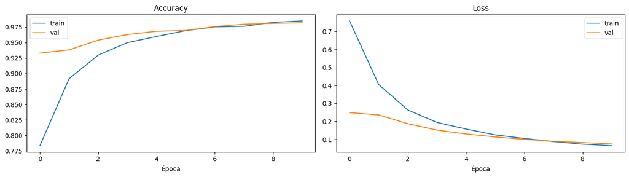

```
33/33 ━━━━━━━━━━━━━━━━━━━━ 5s 164ms/step - accuracy: 0.9855 - loss: 0.0677
Test loss:     0.0656
Test accuracy: 0.9848
```

```python
# Resultados
plot_training(history_ft)

test_loss, test_acc = efficientnet_model.evaluate(test_data)
print(f"Test loss:     {test_loss:.4f}")
print(f"Test accuracy: {test_acc:.4f}")
```

**Comentarios:**  
En segundo caso hemos partido del primer entrenamiento del modelo y le hemos aplicado un fine-tunning. Este segundo entrenamiento ha partido de un estado muy estable, con las capas Dense del modelo entrenadas. Vemos como la precisión empieza bastante alta y va dando saltos más pequeños por el learning rate más bajo llegando a un valor de 0.9848 en test, el mayor hasta el momento.  
Al final lo que ha pasado es que, en la primera iteración el modelo ha llegado a comprender muy bien las características generales de los datos con una muy buena precisión, esta segunda iteración, y para lo que se utiliza el fine-tunning es, una vez que ya tenemos un buen modelo, vamos a hacer que sabiendo lo que hemos aprendido, miremos sus características más concretas, por ello mejoramos considerablemente la precisión.

## 6. Introducción a PyTorch: Red Convolucional Básica (1 punto)

Hasta ahora hemos utilizado TensorFlow/Keras, que nos ofrecen una API de alto nivel muy cómoda mediante los métodos `.fit()` y `.evaluate()`. Sin embargo, en el mundo de la investigación y en gran parte de la industria, **PyTorch** es el *framework* dominante debido a su flexibilidad y a que permite un control más profundo y "pythonico" del flujo de ejecución.

En PyTorch, nosotros mismos debemos definir cómo los datos pasan por la red (`forward pass`) y cómo iteramos sobre los lotes para actualizar los pesos en lo que llamamos el **bucle de entrenamiento** (*training loop*).

**Ejercicio [1 punto]:** Implementa una red convolucional sencilla y entrénala usando PyTorch para clasificar nuestra base de datos.

- **Carga de datos:** Utiliza `torchvision.datasets.ImageFolder` y `DataLoader` para cargar las imágenes de entrenamiento desde la ruta `train_dir`. Aplica transformaciones para redimensionar a 224x224 y convertir a Tensor (lo cual rescala automáticamente a valores entre 0 y 1). Lotes de tamaño 32.
- **Definición del modelo:** Crea una clase que herede de `nn.Module`. Debe contener:
  - Dos capas convolucionales (`nn.Conv2d`), cada una seguida de una activación ReLU y un *Max Pooling* (`nn.MaxPool2d`).
  - Una capa `nn.AdaptiveAvgPool2d((1, 1))` para colapsar las dimensiones espaciales.
  - Una capa lineal de clasificación (`nn.Linear`) con salida a 21 clases.
- **Bucle de entrenamiento:** Define como función de pérdida `nn.CrossEntropyLoss` y utiliza el optimizador Adam (lr=0.001). Escribe un bucle de entrenamiento de **5 épocas** que recorra el DataLoader de entrenamiento e imprima por pantalla la pérdida (*loss*) de cada época.

Comenta brevemente las diferencias que has notado al programar este modelo en PyTorch respecto a Keras.

```python
import torch
import torch.nn as nn
from torchvision import datasets, transforms
from torch.utils.data import DataLoader

# Carga de datos
train_dir = "../input/datasets/apollo2506/landuse-scene-classification/images_train_test_val/"

transform = transforms.Compose([
    transforms.Resize((224, 224)),
    transforms.ToTensor()
])

train_dataset = datasets.ImageFolder(train_dir, transform=transform)
train_loader = DataLoader(train_dataset, batch_size=32, shuffle=True)

print(f"Clases: {train_dataset.classes}")
print(f"Total imágenes: {len(train_dataset)}")
```

```
Clases: ['test', 'train', 'validation']
Total imágenes: 10500
```

```python
# Definición del modelo

class SimpleCNN(nn.Module):
    def __init__(self, num_classes):
        super().__init__()

        self.conv1 = nn.Conv2d(3, 16, kernel_size=3, padding=1)
        self.pool1 = nn.MaxPool2d(2)

        self.conv2 = nn.Conv2d(16, 32, kernel_size=3, padding=1)
        self.pool2 = nn.MaxPool2d(2)

        self.global_pool = nn.AdaptiveAvgPool2d((1, 1))
        self.fc = nn.Linear(32, num_classes)

    def forward(self, x):
        x = self.pool1(nn.functional.relu(self.conv1(x)))
        x = self.pool2(nn.functional.relu(self.conv2(x)))
        x = self.global_pool(x)
        x = torch.flatten(x, 1)
        x = self.fc(x)
        return x

device = torch.device("cuda" if torch.cuda.is_available() else "cpu")

model = SimpleCNN(num_classes=21).to(device)
print(model)
```

```
SimpleCNN(
  (conv1): Conv2d(3, 16, kernel_size=(3, 3), stride=(1, 1), padding=(1, 1))
  (pool1): MaxPool2d(kernel_size=2, stride=2, padding=0, dilation=1, ceil_mode=False)
  (conv2): Conv2d(16, 32, kernel_size=(3, 3), stride=(1, 1), padding=(1, 1))
  (pool2): MaxPool2d(kernel_size=2, stride=2, padding=0, dilation=1, ceil_mode=False)
  (global_pool): AdaptiveAvgPool2d(output_size=(1, 1))
  (fc): Linear(in_features=32, out_features=21, bias=True)
)
```

```python
criterion = nn.CrossEntropyLoss()
optimizer = torch.optim.Adam(model.parameters(), lr=0.001)

for epoch in range(5):
    model.train()
    running_loss = 0.0

    for images, labels in train_loader:
        images, labels = images.to(device), labels.to(device)

        optimizer.zero_grad()
        outputs = model(images)
        loss = criterion(outputs, labels)
        loss.backward()
        optimizer.step()

        running_loss += loss.item()

    epoch_loss = running_loss / len(train_loader)
    print(f"Época {epoch+1}/5 — Loss: {epoch_loss:.4f}")
```

```
Época 1/5 — Loss: 0.9598
Época 2/5 — Loss: 0.8130
Época 3/5 — Loss: 0.8086
Época 4/5 — Loss: 0.8079
Época 5/5 — Loss: 0.8090
```

**Comentarios:**  
Las diferencias sobre todo he notado el bajo nivel que maneja PyTorch. Tienes que especificar con más detalle los pases de las neuronas, no tiene funciones y clases tan desarrolladas como keras y algunas cosas tienes que hacerlas más a mano. Sin embargo, está bien para aprender mejor a hacer las cosas, he tenido que buscar más en detalle hasta encontrar un tutorial directamente y ayudarme de la documentación oficial con keras parece que había más recursos.

**Fuentes:**  
Pon aquí las fuentes utilizadas en la elaboración de la PEC (incluyendo herramientas de IA generativa).

- **Fuentes utilizadas en el ejercicio 1:** Para el tratado de imágenes con Python al buscar me encontré con PIL(pillow) y como solo había que extraer valor máximo y mínimo fue fácil https://pillow.readthedocs.io/en/stable/reference/Image.html
- **Fuentes utilizadas en el ejercicio 2:** Para la creaación de redes con keras seguí el tutorial de esta web https://certidevs.com/tutorial-tensorflow-keras-capas-neuronales  
  Para el plot usé Claude con la pregunta, "una vez entrenada una red neuronal, con su .fit ¿puedo generar el accuracy y lost del entrenamiento completo?"
- **Fuentes utilizadas en el ejercicio 3:** https://certidevs.com/tutorial-tensorflow-keras-preprocesamiento-datos-escalado-normalizacion-estandarizacion y https://keras.io/api/layers/pooling_layers/global_average_pooling2d/
- **Fuentes utilizadas en el ejercicio 4:** Para el apartado de las imágenes le he preguntado a Claude que me ayude con lo siguiente: "Dame el código para visualizar 4 parejas de imágenes originales y reconstruidas por un autoencoder en matplotlib"
- **Fuentes utilizadas en el ejercicio 5:** Usé la documentación de https://keras.io/api/applications/efficientnet/efficientnet_models/#efficientnetb0-function  
  Para el apartado 5.2 le pregunté a Claude si, teniendo la red neuronal del 5.1, poniendo solo "base_model.trainable = True" ya serviria para cambiar el modelo y puedo continuar con la creación de una red neuronal
- **Fuentes utilizadas en el ejercicio 6:** Para saber usar pytorch he encontrado la guia de https://anderfernandez.com/blog/tutorial-de-pytorch-2/  
  Hay una parte para entrenar y crear una red convolucional y seguí ese estilo.  
  Además, para algunas cosas que no iba entendiendo miraba la documentación oficial https://docs.pytorch.org/docs/stable/nn.html